# Group 5 National City Bank Case

De Rooij, Tim

2018-11-26

### 1 Develop an understanding of the purpose of the data mining project

For a new credit product, we have been asked to identify the 100 most likely customers from a prospective customer list. Marketing and sales effort (and budget) will be allocated to this selection of most likely buyers. To achieve this, we will develop a customer propensity model, based on historical data of 4,000 previous calls and mailings combined with supplemental data.

### 2 Obtain the dataset to be used for analysis

We have five datasets to be used for this analysis:

1. Training data: this dataset contains the outcomes of 4,000 previous calls and mailings for a product campaign, which we will use to train and build our customer propensity model
2. Supplemental data: household axiom data
3. Supplemental data: household credit data
4. Supplemental data: household vehicle data
5. New records of prospective customers and their attributes, for which we will make predictions

We start with loading the data.

```r
# load the historical data
historical.df <- read.csv("/Users/TdR/Coding/R/HarvardDataMiningCourse/cases/National City Bank/training/CurrentCustomerMktgResults.csv")

# load the supplemental data
sup.axiom.df <- read.csv("/Users/TdR/Coding/R/HarvardDataMiningCourse/cases/National City Bank/training/householdAxiomData.csv")
sup.credit.df <- read.csv("/Users/TdR/Coding/R/HarvardDataMiningCourse/cases/National City Bank/training/householdCreditData.csv")
sup.vehicle.df <- read.csv("/Users/TdR/Coding/R/HarvardDataMiningCourse/cases/National City Bank/training/householdVehicleData.csv")

# load the prospective customer data
prospects.df <- read.csv("/Users/TdR/Coding/R/HarvardDataMiningCourse/cases/National City Bank/ProspectiveCustomers.csv")
```

### 3. Exploratory Data Analysis (EDA), cleaning, and pre-processing

First we look at the **historical data**, our training data, of a previous marketing campaign. From EDA, we learn the following about this dataset:

- We have 4000 observations (rows) and 12 variables (columns)
- The outcome variable (Y_AccetpedOffer) describes whether a prospect accepted (1) or did not accept (0) the offer
- 1604 of the 4000 subjects accepted the offer, a success ratio of 40.1%
- Other variables include information such as month of last contact, number of contacts, communication type, and the outcome of a previous marketing campaign (if applicable, indicated by PrevAttempts = 1 if there has been a previous campaign)
- ~70% of the communication was by mobile (cellular) phone, ~7% by landline and for 23% of the cases this is unknown
- LastContactDay and LastContactMonth give information about the date of last contact
- ~25% of the contact was in May and ~40% in the summer months (June, July August), ~73% in the period April - August
- The maximum number of contacts equals 43, with a mean of 2.6
- The mean number of days passed after which a customer was contacted from a previous campaign equals 48, or roughly 1.6 months
- Circa 25% of the customers in his set have been subject to a previous campaign, ~34% of which were registered as ‘success’, ~45% as ‘failure’ and ~20% as ‘other’, which could mean that the customer is still in process (this should be checked with the marketing team)

```r
# EDA
dim( historical.df ) # get the dimensions
```

```
## [1] 4000   12
```

```r
names( historical.df ) # get the variable names
```

```
##  [1] "dataID"           "HHuniqueID"       "Communication"
##  [4] "LastContactDay"   "LastContactMonth" "NoOfContacts"
##  [7] "DaysPassed"       "PrevAttempts"     "Outcome"
## [10] "CallStart"        "CallEnd"          "Y_AccetpedOffer"
```

```r
head( historical.df, 4 ) # look at the first 4 rows
```

|  | dataID | HHuniqueID | Communication | LastContactDay | LastContactMonth | NoOfContacts | DaysPassed | PrevAttempts | Outcome | CallStart | CallEnd | Y_AccetpedOffer |
| --- | --- | --- | --- | --- | --- | --- | --- | --- | --- | --- | --- | --- |
| 1 | 1 | HHd4d0af8c72 | telephone | 28 | jan | 2 | -1 | 0 | NA | 13:45:20 | 13:46:30 | 0 |
| 2 | 2 | HH8d3e87c164 | NA | 26 | may | 5 | -1 | 0 | NA | 14:49:03 | 14:52:08 | 0 |
| 3 | 3 | HHdd53ef1db6 | cellular | 3 | jun | 1 | 119 | 1 | failure | 16:30:24 | 16:36:04 | 1 |
| 4 | 4 | HH6fa0de6516 | cellular | 11 | may | 2 | -1 | 0 | NA | 12:06:43 | 12:20:22 | 1 |

```r
str( historical.df ) # look at the data structure
```

```
## 'data.frame':    4000 obs. of  12 variables:
##  $ dataID          : int  1 2 3 4 5 6 7 8 9 10 ...
##  $ HHuniqueID      : Factor w/ 4000 levels "HH001f60887a",..: 3340 2208 3458 1785 3682 1282 948 2673 1885 2512 ...
##  $ Communication   : Factor w/ 2 levels "cellular","telephone": 2 NA 1 1 1 1 1 NA 1 1 ...
##  $ LastContactDay  : int  28 26 3 11 3 22 17 12 18 12 ...
##  $ LastContactMonth: Factor w/ 12 levels "apr","aug","dec",..: 5 9 7 9 7 9 8 9 10 9 ...
##  $ NoOfContacts    : int  2 5 1 2 1 1 1 4 1 2 ...
##  $ DaysPassed      : int  -1 -1 119 -1 -1 109 -1 -1 -1 -1 ...
##  $ PrevAttempts    : int  0 0 1 0 0 1 0 0 0 0 ...
##  $ Outcome         : Factor w/ 3 levels "failure","other",..: NA NA 1 NA NA 1 NA NA NA NA ...
##  $ CallStart       : Factor w/ 3777 levels "10:00:14","10:00:16",..: 1534 1986 2714 832 1895 2064 1209 2354 937 3507 ...
##  $ CallEnd         : Factor w/ 3764 levels "10:00:05","10:00:10",..: 1528 2007 2725 928 1907 2132 1213 2344 945 3534 ...
##  $ Y_AccetpedOffer : int  0 0 1 1 0 1 1 0 0 0 ...
```

```r
summary( historical.df ) # obtain the summary per variable
```

```
##      dataID            HHuniqueID     Communication  LastContactDay
##  Min.   :   1   HH001f60887a:   1   cellular :2831   Min.   : 1.00
##  1st Qu.:1001   HH003c364a47:   1   telephone: 267   1st Qu.: 8.00
##  Median :2000   HH003c84d6ad:   1   NA's     : 902   Median :16.00
##  Mean   :2000   HH0053b38c31:   1                    Mean   :15.72
##  3rd Qu.:3000   HH0057415ea9:   1                    3rd Qu.:22.00
##  Max.   :4000   HH0083f9d484:   1                    Max.   :31.00
##                 (Other)     :3994
##  LastContactMonth  NoOfContacts      DaysPassed      PrevAttempts
##  may    :1049     Min.   : 1.000   Min.   : -1.00   Min.   : 0.0000
##  jul    : 573     1st Qu.: 1.000   1st Qu.: -1.00   1st Qu.: 0.0000
##  aug    : 536     Median : 2.000   Median : -1.00   Median : 0.0000
##  jun    : 454     Mean   : 2.607   Mean   : 48.71   Mean   : 0.7175
##  nov    : 347     3rd Qu.: 3.000   3rd Qu.: -1.00   3rd Qu.: 0.0000
##  apr    : 306     Max.   :43.000   Max.   :854.00   Max.   :58.0000
##  (Other): 735
##     Outcome        CallStart        CallEnd     Y_AccetpedOffer
##  failure: 437   10:42:44:   3   10:22:30:   3   Min.   :0.000
##  other  : 195   11:48:25:   3   10:52:24:   3   1st Qu.:0.000
##  success: 326   13:54:34:   3   11:27:46:   3   Median :0.000
##  NA's   :3042   15:27:56:   3   10:05:06:   2   Mean   :0.401
##                 15:48:27:   3   10:05:25:   2   3rd Qu.:1.000
##                 17:02:39:   3   10:08:37:   2   Max.   :1.000
##                 (Other) :3982   (Other) :3985
```

```r
sum( historical.df$Y_AccetpedOffer ) # total number of success cases
```

```
## [1] 1604
```

Visualizations allow us to better understand the data. Examples of insights gained through data visualization are:

- Over 7,000 contacts were conducted by celluar communication.

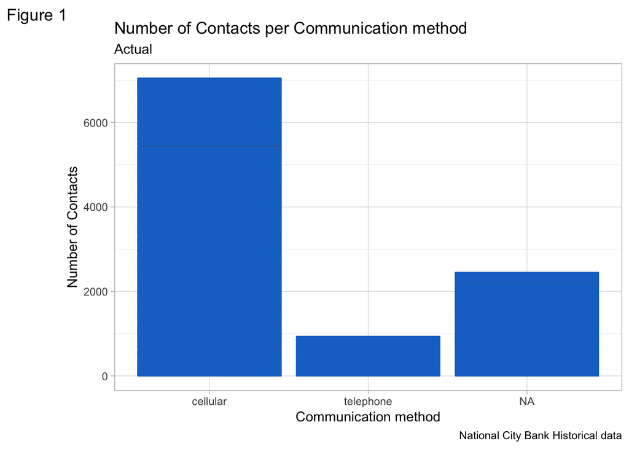

```r
# VISUALIZATIONS
# Number of contacts per communication method
ggplot( historical.df, aes( x = Communication, y = NoOfContacts ) ) +
  geom_bar( stat = "identity", colour = "Dodgerblue3" ) +
  labs( title = "Number of Contacts per Communication method",
       subtitle = "Actual",
       caption = "National City Bank Historical data",
       tag = "Figure 1",
       x = "Communication method",
       y = "Number of Contacts",
       colour = "Gears" ) +
  theme_light()
```

Observations regarding pre-processing and cleaning:

1. Typo in variable name “Y_AccetpedOffer”, which we will correct (same holds for prospects dataset)
2. CallStart and CallEnd do not provide relevant insights by itself, but we can use these to create a new variable to calculate the length of the call, and use this in the training of sales reps. Because this information is not available in the prospects data, we cannot use it in our prediction model (CallStart and Callend are now of class Factor and will have to be converted to a different format before we can use it for analysis)
3. We have two ID variables, one of them (dataID) is redundant and can be excluded (confirmed after EDA on supplemental data)
4. We will transform LastContactDay class from integer to factor

```r
# 1 correct typo
colnames( historical.df )[colnames( historical.df ) == "Y_AccetpedOffer" ] <- "Y_AcceptedOffer"
colnames( prospects.df )[colnames( prospects.df ) == "Y_AccetpedOffer" ] <- "Y_AcceptedOffer"
names( historical.df )
```

```
##  [1] "dataID"           "HHuniqueID"       "Communication"
##  [4] "LastContactDay"   "LastContactMonth" "NoOfContacts"
##  [7] "DaysPassed"       "PrevAttempts"     "Outcome"
## [10] "CallStart"        "CallEnd"          "Y_AcceptedOffer"
```

```r
names( prospects.df )
```

```
##  [1] "dataID"           "HHuniqueID"       "Communication"
##  [4] "LastContactDay"   "LastContactMonth" "NoOfContacts"
##  [7] "DaysPassed"       "PrevAttempts"     "Outcome"
## [10] "Y_AcceptedOffer"
```

```r
# 2 create new variable "CallDuration"
historical.df$CallEnd <- chron( times = historical.df$CallEnd ) # convert to time using chron()
historical.df$CallStart <- chron( times = historical.df$CallStart ) # convert to time using chron()
historical.df$CallDuration <- historical.df$CallEnd - historical.df$CallStart
# 3 Drop redundant ID variable "dataID"
historical.df$dataID <- NULL
# 4 Transsform class LastContactDay
historical.df$LastContactDay <- as.factor( historical.df$LastContactDay )
```

When we visualize our newly created variable for additional insights we make a number of observations:

- Although the summary statistics tell us that the mean duration is 5 minutes and 51 seconds, by looking at the histogram we can see that calls tend to be shorter than 5 minutes.
- The mean is skewed by outliers (e.g., Maximum = 54 minutes and 13 seconds).
- A more useful indicator of typical call duration is the Median: 3 minutes and 52 seconds.

When we compare differences in call duration for success and no success cases we observe:

- Offer Accepted: mean duration = 00:09:12, median duration = 00:07:27
- Not Accepted: mean duration = 00:03:36, median duration = 00:02:37

Maybe not too surprising, the duration of calls that led to the acceptance of an offer were almost 3x as long as calls that did not lead to offers.

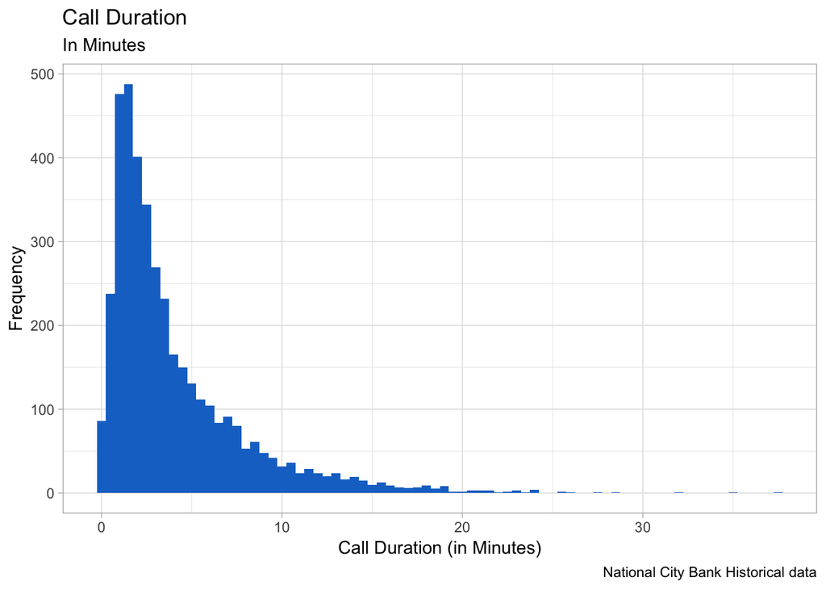

```r
# create historgram
ggplot( historical.df, aes( x = CallDuration * 1000 ) ) +
  geom_histogram( fill = "Dodgerblue3", binwidth = 0.5 ) +
  labs( title = "Call Duration",
       subtitle = "In Minutes",
       caption = "National City Bank Historical data",
       #tag = "Figure 2",
       x = "Call Duration (in Minutes)",
       y = "Frequency",
       colour = "Gears" ) +
  theme_light()
```

```r
# obtain summary statistics
summary( historical.df$CallDuration )
```

```
##     Min.  1st Qu.   Median     Mean  3rd Qu.     Max.
## 00:00:05 00:02:06 00:03:52 00:05:51 00:07:40 00:54:13
```

```r
# calculate mean and median duration for success case
mean( historical.df$CallDuration[ historical.df$Y_AcceptedOffer == 1 ])
```

```
## [1] 00:09:12
```

```r
mean( historical.df$CallDuration[ historical.df$Y_AcceptedOffer == 0 ])
```

```
## [1] 00:03:36
```

```r
median( historical.df$CallDuration[ historical.df$Y_AcceptedOffer == 1 ])
```

```
## [1] 00:07:27
```

```r
median( historical.df$CallDuration[ historical.df$Y_AcceptedOffer == 0 ])
```

```
## [1] 00:02:37
```

Assessment of No Of Contacts and acceptance.

```r
accept.noofcontact <- historical.df[ historical.df$Y_AcceptedOffer == 1,
                                     "NoOfContacts" ]
notaccept.noofcontact <- historical.df[ historical.df$Y_AcceptedOffer == 0,
                                        "NoOfContacts" ]
mean( accept.noofcontact, na.rm = TRUE )
```

```
## [1] 2.177057
```

```r
mean( notaccept.noofcontact, na.rm = TRUE )
```

```
## [1] 2.895242
```

Next, we look at the **suplemental data**. From EDA, we learn the following:

General observations:

- For the three sets we have 5000 rows each, suggesting that we can use this data to combine with both the historical data (4000 observations) and the prospective customer data (1000 observations), based on customers unique ID’s
- The Column “HHuniqueID” will be the identifier to use for joining the data as part of pre-processing

Axioms data key stats:

- 11 variables providing household information, including gender, age, marital status, job category, level of education, annual donations, luxury shopping behavior, and digital habits
- ~50/50 split of male and female customers
- Mean age is 41, median age is 39, the oldest person in the set is 95, youngest is 18
- 22% of customers are in job category ‘management’, 19% ‘blue-collar’, 16% ‘technician’, 12% ‘admin’, 8% ‘services’, 22% ‘other’
- 12% is divorced, 58% is married, 30% is single
- 14% had primary education, 50% had secondary education, 32% had tertiary education

```r
# EDA
dim( sup.axiom.df ) # get the dimensions
```

```
## [1] 5000   11
```

```r
names( sup.axiom.df ) # get the variable names
```

```
##  [1] "HHuniqueID"               "headOfhouseholdGender"
##  [3] "annualDonations"          "EstRace"
##  [5] "PetsPurchases"            "DigitalHabits_5_AlwaysOn"
##  [7] "AffluencePurchases"       "Age"
##  [9] "Job"                      "Marital"
## [11] "Education"
```

```r
head( sup.axiom.df, 4 ) # look at the first 4 rows
```

|  | HHuniqueID | headOfhouseholdGender | annualDonations | EstRace | PetsPurchases | DigitalHabits_5_AlwaysOn | AffluencePurchases | Age | Job | Marital | Education |
| --- | --- | --- | --- | --- | --- | --- | --- | --- | --- | --- | --- |
| 1 | HHd4d0af8c72 | F |  | Fijian | TRUE | 4 | FALSE | 32 | management | single | tertiary |
| 2 | HH8d3e87c164 | M |  |  | TRUE | 2 | FALSE | 32 | blue-collar | married | primary |
| 3 | HHdd53ef1db6 | F |  |  | FALSE | 1 | FALSE | 29 | management | single | tertiary |
| 4 | HH6fa0de6516 | F |  |  | TRUE | 1 | TRUE | 25 | student | single | primary |

```r
str( sup.axiom.df ) # look at the data structure
```

```
## 'data.frame':    5000 obs. of  11 variables:
##  $ HHuniqueID              : Factor w/ 5000 levels "HH0012228ae0",..: 4161 2774 4316 2240 4600 1620 1200 3334 2370 3146 ...
##  $ headOfhouseholdGender   : Factor w/ 2 levels "F","M": 1 2 1 1 1 1 1 1 2 2 ...
##  $ annualDonations         : Factor w/ 554 levels "","$1,000.31 ",..: 1 1 1 1 1 1 1 1 1 1 ...
##  $ EstRace                 : Factor w/ 94 levels "","Alaska Native",..: 37 1 1 1 66 1 1 39 1 1 ...
##  $ PetsPurchases           : logi  TRUE TRUE FALSE TRUE TRUE TRUE ...
##  $ DigitalHabits_5_AlwaysOn: int  4 2 1 1 3 3 1 3 4 4 ...
##  $ AffluencePurchases      : logi  FALSE FALSE FALSE TRUE TRUE FALSE ...
##  $ Age                     : int  32 32 29 25 30 32 37 35 30 30 ...
##  $ Job                     : Factor w/ 11 levels "admin.","blue-collar",..: 5 2 5 9 5 10 1 5 1 2 ...
##  $ Marital                 : Factor w/ 3 levels "divorced","married",..: 3 2 3 3 2 3 3 1 2 2 ...
##  $ Education               : Factor w/ 3 levels "primary","secondary",..: 3 1 3 1 3 3 3 3 2 2 ...
```

```r
summary( sup.axiom.df ) # obtain the summary per variable
```

```
##         HHuniqueID   headOfhouseholdGender   annualDonations
##  HH0012228ae0:   1   F:2502                          :4446
##  HH001f60887a:   1   M:2498                $384.43   :   2
##  HH002b0eb251:   1                         $1,000.31 :   1
##  HH003c364a47:   1                         $1,002.68 :   1
##  HH003c84d6ad:   1                         $1,003.19 :   1
##  HH0053b38c31:   1                         $1,011.93 :   1
##  (Other)     :4994                         (Other)   : 548
##                EstRace     PetsPurchases   DigitalHabits_5_AlwaysOn
##                    :3838   Mode :logical   Min.   :1.000
##  Yaqui             :  22   FALSE:2513      1st Qu.:2.000
##  Melanesian        :  20   TRUE :2487      Median :3.000
##  Alaskan Athabascan:  19                   Mean   :3.018
##  Bolivian          :  19                   3rd Qu.:4.000
##  Comanche          :  19                   Max.   :5.000
##  (Other)           :1063
##  AffluencePurchases      Age                 Job           Marital
##  Mode :logical      Min.   :18.00   management :1114   divorced: 588
##  FALSE:2541         1st Qu.:32.00   blue-collar: 937   married :2898
##  TRUE :2459         Median :39.00   technician : 823   single  :1514
##                     Mean   :41.27   admin.     : 586
##                     3rd Qu.:49.00   services   : 414
##                     Max.   :95.00   (Other)    :1102
##                                     NA's       :  24
##      Education
##  primary  : 694
##  secondary:2489
##  tertiary :1601
##  NA's     : 216
##
##
##
```

When we visualize the age data and look at the peak of the curve, we observe a distribution that seems skewed towards younger people. However, below 32 years old represent only 25% of the data in our set (the 1st Quantile). The Median age is 39 and 75% of the people in our set are younger than 49.

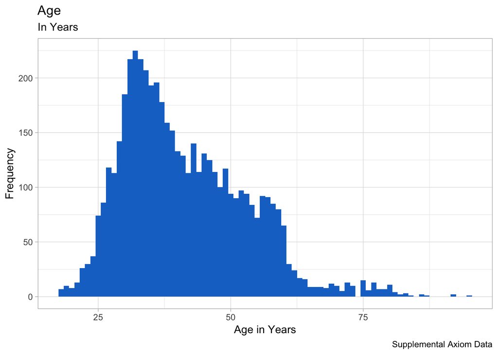

```r
# visualize
ggplot( sup.axiom.df, aes( x = Age ) ) +
  geom_histogram( fill = "Dodgerblue3", binwidth = 1 ) +
  labs( title = "Age",
       subtitle = "In Years",
       caption = "Supplemental Axiom Data",
       # tag = "Figure 3",
       x = "Age in Years",
       y = "Frequency",
       colour = "Gears" ) +
  theme_light()
```

Observations regarding pre-processing and cleaning:

- Annual donations has to be converted to numeric

```r
# convert donations to numeric
sup.axiom.df$annualDonations <- gsub( "$", "", sup.axiom.df$annualDonations, fixed = TRUE )
sup.axiom.df$annualDonations <- gsub( ",", "", sup.axiom.df$annualDonations, fixed = TRUE )
sup.axiom.df$annualDonations <- as.numeric( sup.axiom.df$annualDonations )
str(sup.axiom.df$annualDonations) # confirm class
```

```
##  num [1:5000] NA NA NA NA NA NA NA NA NA NA ...
```

```r
# get summary
summary( sup.axiom.df$annualDonations )
```

```
##    Min. 1st Qu.  Median    Mean 3rd Qu.    Max.    NA's
##    1.49  304.19  655.96  646.65  988.71 1336.85    4446
```

When we visualize the annual donations data we observe a wide variety in the amounts, ranging from close to USD 0 up to USD 1337 (note that we have 4446 NA’s, or 88.9% of the observations).

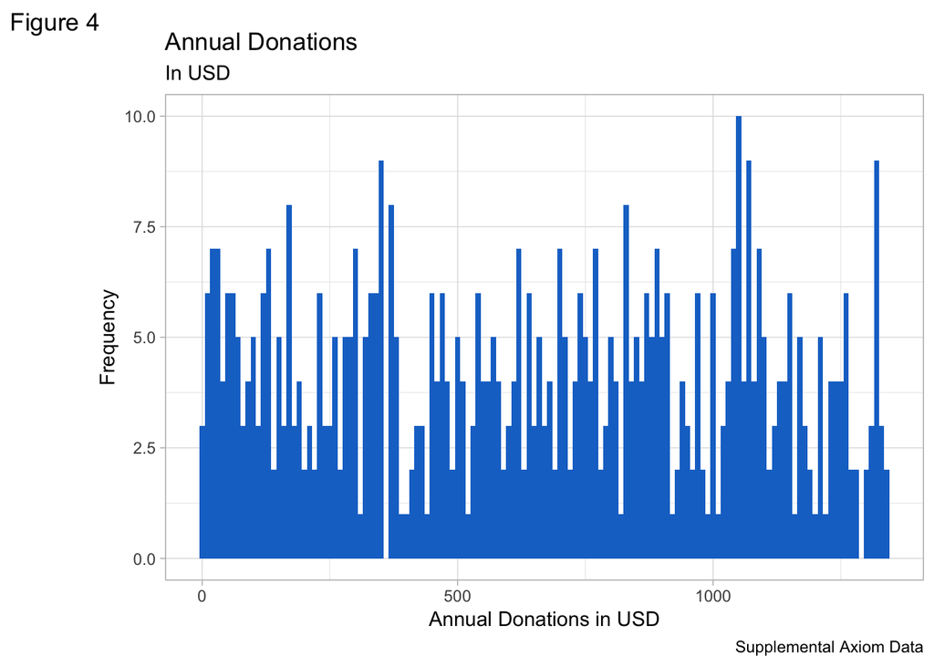

```r
# visualize
ggplot( sup.axiom.df, aes( x = annualDonations ) ) +
  geom_histogram( fill = "Dodgerblue3", binwidth = 10 ) +
  labs( title = "Annual Donations",
       subtitle = "In USD",
       caption = "Supplemental Axiom Data",
       tag = "Figure 4",
       x = "Annual Donations in USD",
       y = "Frequency",
       colour = "Gears" ) +
  theme_light()
```

Credit data key stats:

- 5 variables for 5000 observations, including default (binary), recent balance, insurance (binary), and whether the customer has a car loan (binary)
- The mean credit balance is USD 1,506, with a maximum of USD 98,417

```r
# EDA
dim( sup.credit.df ) # get the dimensions
```

```
## [1] 5000    5
```

```r
names( sup.credit.df ) # get the variable names
```

```
## [1] "HHuniqueID"      "DefaultOnRecord" "RecentBalance"   "HHInsurance"
## [5] "CarLoan"
```

```r
head( sup.credit.df, 4 ) # look at the first 4 rows
```

|  | HHuniqueID | DefaultOnRecord | RecentBalance | HHInsurance | CarLoan |
| --- | --- | --- | --- | --- | --- |
| 1 | HHd4d0af8c72 | 0 | 1218 | 1 | 0 |
| 2 | HH8d3e87c164 | 0 | 1156 | 1 | 0 |
| 3 | HHdd53ef1db6 | 0 | 637 | 1 | 0 |
| 4 | HH6fa0de6516 | 0 | 373 | 1 | 0 |

```r
str( sup.credit.df ) # look at the data structure
```

```
## 'data.frame':    5000 obs. of  5 variables:
##  $ HHuniqueID     : Factor w/ 5000 levels "HH0012228ae0",..: 4161 2774 4316 2240 4600 1620 1200 3334 2370 3146 ...
##  $ DefaultOnRecord: int  0 0 0 0 0 0 0 0 0 0 ...
##  $ RecentBalance  : int  1218 1156 637 373 2694 1625 1000 538 187 3 ...
##  $ HHInsurance    : int  1 1 1 1 0 0 1 1 1 1 ...
##  $ CarLoan        : int  0 0 0 0 0 0 0 0 0 1 ...
```

```r
summary( sup.credit.df ) # obtain the summary per variable
```

```
##         HHuniqueID   DefaultOnRecord  RecentBalance    HHInsurance
##  HH0012228ae0:   1   Min.   :0.0000   Min.   :-3058   Min.   :0.0000
##  HH001f60887a:   1   1st Qu.:0.0000   1st Qu.:  113   1st Qu.:0.0000
##  HH002b0eb251:   1   Median :0.0000   Median :  538   Median :0.0000
##  HH003c364a47:   1   Mean   :0.0142   Mean   : 1506   Mean   :0.4968
##  HH003c84d6ad:   1   3rd Qu.:0.0000   3rd Qu.: 1615   3rd Qu.:1.0000
##  HH0053b38c31:   1   Max.   :1.0000   Max.   :98417   Max.   :1.0000
##  (Other)     :4994
##     CarLoan
##  Min.   :0.0000
##  1st Qu.:0.0000
##  Median :0.0000
##  Mean   :0.1306
##  3rd Qu.:0.0000
##  Max.   :1.0000
##
```

When we visualize the credit balance data the graph is difficult to read because of the outliers present in the data.

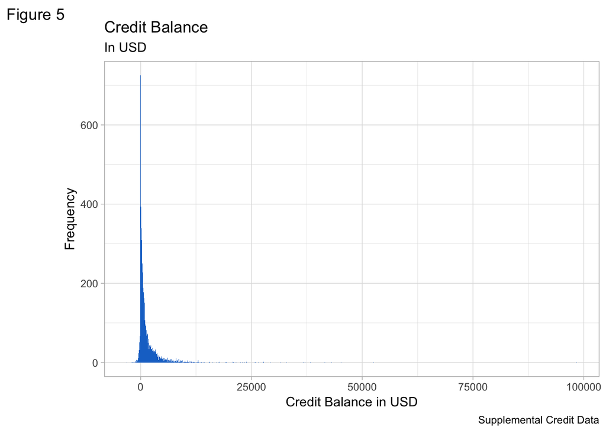

```r
# visualize
ggplot( sup.credit.df, aes( x = RecentBalance ) ) +
  geom_histogram( fill = "Dodgerblue3", binwidth = 100 ) +
  # xlim( -3500, 3500 ) +
  labs( title = "Credit Balance",
       subtitle = "In USD",
       caption = "Supplemental Credit Data",
       tag = "Figure 5",
       x = "Credit Balance in USD",
       y = "Frequency",
       colour = "Gears" ) +
  theme_light()
```

The distribution becomes more clear when we scale the x-axis.

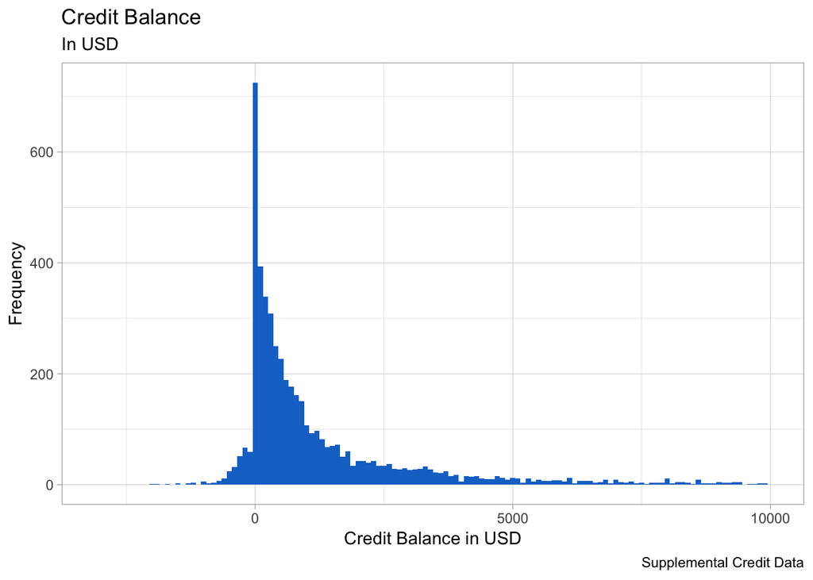

```r
# visualize
ggplot( sup.credit.df, aes( x = RecentBalance ) ) +
  geom_histogram( fill = "Dodgerblue3", binwidth = 100 ) +
  xlim( -3100, 10000 ) +
  labs( title = "Credit Balance",
       subtitle = "In USD",
       caption = "Supplemental Credit Data",
       #tag = "Figure 6",
       x = "Credit Balance in USD",
       y = "Frequency",
       colour = "Gears" ) +
  theme_light()
```

Vehicle data key stats:

- We have 5000 observations of 4 variables
- Variables include car brand, car model and car year
- The top 5 car brands in the set are Chevrolet, Ford, Dodge, Toyota and GMC, together representing 31% of the data
- The oldest car from the set is from 1909, the newest from 2013, the average year is 2000

```r
# EDA
dim( sup.vehicle.df ) # get the dimensions
```

```
## [1] 5000    4
```

```r
names( sup.vehicle.df ) # get the variable names
```

```
## [1] "HHuniqueID" "carMake"    "carModel"   "carYr"
```

```r
head( sup.vehicle.df, 4 ) # look at the first 4 rows
```

|  | HHuniqueID | carMake | carModel | carYr |
| --- | --- | --- | --- | --- |
| 1 | HHd4d0af8c72 | Mitsubishi | Eclipse | 2004 |
| 2 | HH8d3e87c164 | Hyundai | Elantra | 1999 |
| 3 | HHdd53ef1db6 | Ford | Explorer Sport | 2001 |
| 4 | HH6fa0de6516 | Buick | Regal | 1998 |

```r
str( sup.vehicle.df ) # look at the data structure
```

```
## 'data.frame':    5000 obs. of  4 variables:
##  $ HHuniqueID: Factor w/ 5000 levels "HH0012228ae0",..: 4161 2774 4316 2240 4600 1620 1200 3334 2370 3146 ...
##  $ carMake   : Factor w/ 70 levels "","Acura","Alfa Romeo",..: 46 28 22 10 30 28 65 6 12 33 ...
##  $ carModel  : Factor w/ 874 levels "","1 Series",..: 281 287 324 636 560 99 467 676 165 691 ...
##  $ carYr     : int  2004 1999 2001 1998 1998 2003 2010 2007 1975 2008 ...
```

```r
summary( sup.vehicle.df ) # obtain the summary per variable
```

```
##         HHuniqueID         carMake         carModel        carYr
##  HH0012228ae0:   1   Chevrolet : 417           : 175   Min.   :1909
##  HH001f60887a:   1   Ford      : 403   Corvette:  37   1st Qu.:1995
##  HH002b0eb251:   1   Dodge     : 260   Accord  :  31   Median :2002
##  HH003c364a47:   1   Toyota    : 237   E-Class :  28   Mean   :2000
##  HH003c84d6ad:   1   GMC       : 231   Mustang :  28   3rd Qu.:2007
##  HH0053b38c31:   1   Mitsubishi: 186   Taurus  :  27   Max.   :2013
##  (Other)     :4994   (Other)   :3266   (Other) :4674   NA's   :255
```

The final set we explore is the data on new prospects. EDA learns us the following:

- 10 variables for 1000 observations (prospect customers)
- Same variables as in our Historical data set, except for CallStart and CallEnd

```r
# EDA
dim( prospects.df ) # get the dimensions
```

```
## [1] 1000   10
```

```r
names( prospects.df ) # get the variable names
```

```
##  [1] "dataID"           "HHuniqueID"       "Communication"
##  [4] "LastContactDay"   "LastContactMonth" "NoOfContacts"
##  [7] "DaysPassed"       "PrevAttempts"     "Outcome"
## [10] "Y_AcceptedOffer"
```

```r
head( prospects.df, 4 ) # look at the first 4 rows
```

|  | dataID | HHuniqueID | Communication | LastContactDay | LastContactMonth | NoOfContacts | DaysPassed | PrevAttempts | Outcome | Y_AcceptedOffer |
| --- | --- | --- | --- | --- | --- | --- | --- | --- | --- | --- |
| 1 | 4001 | HH0534604f12 | NA | 12 | may | 12 | -1 | 0 | NA | NA |
| 2 | 4002 | HH5e71c6ec08 | cellular | 24 | jul | 1 | -1 | 0 | NA | NA |
| 3 | 4003 | HH4cd1f61b84 | cellular | 15 | may | 10 | -1 | 0 | NA | NA |
| 4 | 4004 | HHf444cf2934 | cellular | 9 | nov | 1 | -1 | 0 | NA | NA |

```r
str( prospects.df ) # look at the data structure
```

```
## 'data.frame':    1000 obs. of  10 variables:
##  $ dataID          : int  4001 4002 4003 4004 4005 4006 4007 4008 4009 4010 ...
##  $ HHuniqueID      : Factor w/ 1000 levels "HH0012228ae0",..: 27 388 322 953 769 310 613 291 82 842 ...
##  $ Communication   : Factor w/ 2 levels "cellular","telephone": NA 1 1 1 1 1 1 1 NA 1 ...
##  $ LastContactDay  : int  12 24 15 9 2 2 2 3 27 21 ...
##  $ LastContactMonth: Factor w/ 12 levels "apr","aug","dec",..: 9 6 9 10 4 6 4 1 9 10 ...
##  $ NoOfContacts    : int  12 1 10 1 1 1 1 1 1 2 ...
##  $ DaysPassed      : int  -1 -1 -1 -1 -1 399 -1 302 -1 -1 ...
##  $ PrevAttempts    : int  0 0 0 0 0 3 0 3 0 0 ...
##  $ Outcome         : Factor w/ 3 levels "failure","other",..: NA NA NA NA NA 3 NA 1 NA NA ...
##  $ Y_AcceptedOffer : logi  NA NA NA NA NA NA ...
```

```r
summary( prospects.df ) # obtain the summary per variable
```

```
##      dataID            HHuniqueID    Communication LastContactDay
##  Min.   :4001   HH0012228ae0:  1   cellular :698   Min.   : 1.00
##  1st Qu.:4251   HH002b0eb251:  1   telephone: 81   1st Qu.: 8.00
##  Median :4500   HH00b9f84f33:  1   NA's     :221   Median :15.00
##  Mean   :4500   HH00c2bb01af:  1                   Mean   :15.55
##  3rd Qu.:4750   HH00d436dd51:  1                   3rd Qu.:21.00
##  Max.   :5000   HH011ae3bd0a:  1                   Max.   :31.00
##                 (Other)     :994
##  LastContactMonth  NoOfContacts      DaysPassed      PrevAttempts
##  may    :269      Min.   : 1.000   Min.   : -1.00   Min.   : 0.000
##  jul    :142      1st Qu.: 1.000   1st Qu.: -1.00   1st Qu.: 0.000
##  aug    :128      Median : 2.000   Median : -1.00   Median : 0.000
##  jun    :107      Mean   : 2.508   Mean   : 51.65   Mean   : 0.806
##  apr    : 92      3rd Qu.: 3.000   3rd Qu.: -1.00   3rd Qu.: 0.000
##  nov    : 73      Max.   :34.000   Max.   :586.00   Max.   :20.000
##  (Other):189
##     Outcome    Y_AcceptedOffer
##  failure:111   Mode:logical
##  other  : 53   NA's:1000
##  success: 79
##  NA's   :757
##
##
##
```

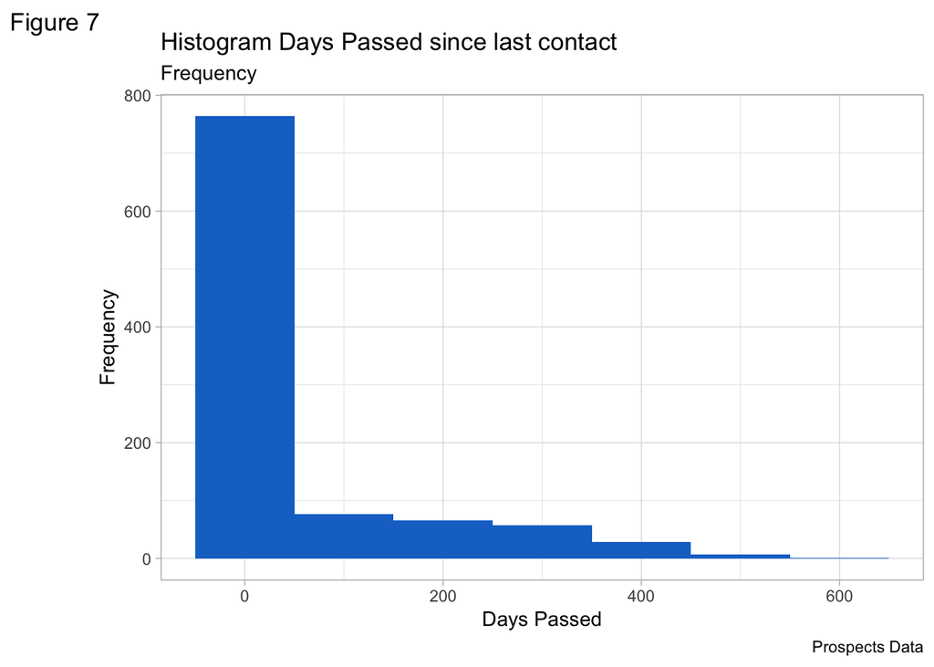

```r
# plot Days Passed
ggplot( prospects.df, aes( x = DaysPassed ) ) +
  geom_histogram( fill = "Dodgerblue3", binwidth = 100 ) +
  labs( title = "Histogram Days Passed since last contact",
       subtitle = "Frequency",
       caption = "Prospects Data",
       tag = "Figure 7",
       x = "Days Passed",
       y = "Frequency",
       colour = "Gears" ) +
  theme_light()
```

```r
# get median value Days Passed
median( prospects.df$DaysPassed )
```

```
## [1] -1
```

Observations regarding pre-processing and cleaning:

1. We have two ID variables, one of them (dataID) is redundant and can be excluded (confirmed after EDA on supplemental data)
2. To use LastContactDay, class needs to be transformed from integer to factor
3. The median value of DaysPassed equals -1. Since -1 days passed is illogical, it could be that the -1 actually suggests ‘not available’ or ‘NA’. For our analysis, we will drop this variable (see under step 4, reduce data dimension)
4. The variables “PreviousAttempts” and “Outcome” are related, because the latter provides information about the result of the previous attempts (if any). “Success” suggests that the customer accepted the offer, which is what we are actually trying predict and capture in the variable “Y_AcceptedOffer”. This seems conflicting. We also know that we have many missing values for the “Outcome” variable: 76% is “NA”. We therefore suggest to exclude these two variables in step 4, data dimension reduction

```r
# 1 drop ID variable
prospects.df$dataID <- NULL
# 2 transform data class
prospects.df$LastContactDay <- as.factor( prospects.df$LastContactDay )
str(prospects.df)
```

```
## 'data.frame':    1000 obs. of  9 variables:
##  $ HHuniqueID      : Factor w/ 1000 levels "HH0012228ae0",..: 27 388 322 953 769 310 613 291 82 842 ...
##  $ Communication   : Factor w/ 2 levels "cellular","telephone": NA 1 1 1 1 1 1 1 NA 1 ...
##  $ LastContactDay  : Factor w/ 31 levels "1","2","3","4",..: 12 24 15 9 2 2 2 3 27 21 ...
##  $ LastContactMonth: Factor w/ 12 levels "apr","aug","dec",..: 9 6 9 10 4 6 4 1 9 10 ...
##  $ NoOfContacts    : int  12 1 10 1 1 1 1 1 1 2 ...
##  $ DaysPassed      : int  -1 -1 -1 -1 -1 399 -1 302 -1 -1 ...
##  $ PrevAttempts    : int  0 0 0 0 0 3 0 3 0 0 ...
##  $ Outcome         : Factor w/ 3 levels "failure","other",..: NA NA NA NA NA 3 NA 1 NA NA ...
##  $ Y_AcceptedOffer : logi  NA NA NA NA NA NA ...
```

We have completed our Exploratory Data Analysis. Next step is to combine the historical and prospect data with supplemental data.

```r
# combine data for historical set
hist.join.axi <- inner_join( historical.df,
                             sup.axiom.df,
                             by = "HHuniqueID" )
hist.join.crd <- inner_join( hist.join.axi,
                             sup.credit.df,
                             by = "HHuniqueID" )
combined.historical.df <- inner_join( hist.join.crd,
                             sup.vehicle.df,
                             by = "HHuniqueID" )
# examine new data set
head( combined.historical.df, 4 )
```

|  | HHuniqueID | Communication | LastContactDay | LastContactMonth | NoOfContacts | DaysPassed | PrevAttempts | Outcome | CallStart | CallEnd | Y_AcceptedOffer | CallDuration | headOfhouseholdGender | annualDonations | EstRace | PetsPurchases | DigitalHabits_5_AlwaysOn | AffluencePurchases | Age | Job | Marital | Education | DefaultOnRecord | RecentBalance | HHInsurance | CarLoan | carMake | carModel | carYr |
| --- | --- | --- | --- | --- | --- | --- | --- | --- | --- | --- | --- | --- | --- | --- | --- | --- | --- | --- | --- | --- | --- | --- | --- | --- | --- | --- | --- | --- | --- |
| 1 | HHd4d0af8c72 | telephone | 28 | jan | 2 | -1 | 0 | NA | 13:45:20 | 13:46:30 | 0 | 00:01:10 | F | NA | Fijian | TRUE | 4 | FALSE | 32 | management | single | tertiary | 0 | 1218 | 1 | 0 | Mitsubishi | Eclipse | 2004 |
| 2 | HH8d3e87c164 | NA | 26 | may | 5 | -1 | 0 | NA | 14:49:03 | 14:52:08 | 0 | 00:03:05 | M | NA |  | TRUE | 2 | FALSE | 32 | blue-collar | married | primary | 0 | 1156 | 1 | 0 | Hyundai | Elantra | 1999 |
| 3 | HHdd53ef1db6 | cellular | 3 | jun | 1 | 119 | 1 | failure | 16:30:24 | 16:36:04 | 1 | 00:05:40 | F | NA |  | FALSE | 1 | FALSE | 29 | management | single | tertiary | 0 | 637 | 1 | 0 | Ford | Explorer Sport | 2001 |
| 4 | HH6fa0de6516 | cellular | 11 | may | 2 | -1 | 0 | NA | 12:06:43 | 12:20:22 | 1 | 00:13:39 | F | NA |  | TRUE | 1 | TRUE | 25 | student | single | primary | 0 | 373 | 1 | 0 | Buick | Regal | 1998 |

```r
str( combined.historical.df )
```

```
## 'data.frame':    4000 obs. of  29 variables:
##  $ HHuniqueID              : chr  "HHd4d0af8c72" "HH8d3e87c164" "HHdd53ef1db6" "HH6fa0de6516" ...
##  $ Communication           : Factor w/ 2 levels "cellular","telephone": 2 NA 1 1 1 1 1 NA 1 1 ...
##  $ LastContactDay          : Factor w/ 31 levels "1","2","3","4",..: 28 26 3 11 3 22 17 12 18 12 ...
##  $ LastContactMonth        : Factor w/ 12 levels "apr","aug","dec",..: 5 9 7 9 7 9 8 9 10 9 ...
##  $ NoOfContacts            : int  2 5 1 2 1 1 1 4 1 2 ...
##  $ DaysPassed              : int  -1 -1 119 -1 -1 109 -1 -1 -1 -1 ...
##  $ PrevAttempts            : int  0 0 1 0 0 1 0 0 0 0 ...
##  $ Outcome                 : Factor w/ 3 levels "failure","other",..: NA NA 1 NA NA 1 NA NA NA NA ...
##  $ CallStart               : 'times' num  13:45:20 14:49:03 16:30:24 12:06:43 14:35:44 ...
##   ..- attr(*, "format")= chr "h:m:s"
##  $ CallEnd                 : 'times' num  13:46:30 14:52:08 16:36:04 12:20:22 14:38:56 ...
##   ..- attr(*, "format")= chr "h:m:s"
##  $ Y_AcceptedOffer         : int  0 0 1 1 0 1 1 0 0 0 ...
##  $ CallDuration            : 'times' num  00:01:10 00:03:05 00:05:40 00:13:39 00:03:12 ...
```

[output cut: 18 more lines]

```r
length( unique( combined.historical.df$HHuniqueID ) ) # double-check uniqueness of IDs
```

```
## [1] 4000
```

```r
names( combined.historical.df )
```

```
##  [1] "HHuniqueID"               "Communication"
##  [3] "LastContactDay"           "LastContactMonth"
##  [5] "NoOfContacts"             "DaysPassed"
##  [7] "PrevAttempts"             "Outcome"
##  [9] "CallStart"                "CallEnd"
## [11] "Y_AcceptedOffer"          "CallDuration"
## [13] "headOfhouseholdGender"    "annualDonations"
## [15] "EstRace"                  "PetsPurchases"
## [17] "DigitalHabits_5_AlwaysOn" "AffluencePurchases"
## [19] "Age"                      "Job"
## [21] "Marital"                  "Education"
## [23] "DefaultOnRecord"          "RecentBalance"
## [25] "HHInsurance"              "CarLoan"
## [27] "carMake"                  "carModel"
## [29] "carYr"
```

```r
summary( combined.historical.df )
```

```
##   HHuniqueID          Communication  LastContactDay LastContactMonth
##  Length:4000        cellular :2831   18     : 203   may    :1049
##  Class :character   telephone: 267   20     : 196   jul    : 573
##  Mode  :character   NA's     : 902   13     : 171   aug    : 536
##                                      30     : 167   jun    : 454
##                                      15     : 165   nov    : 347
##                                      17     : 163   apr    : 306
##                                      (Other):2935   (Other): 735
##   NoOfContacts      DaysPassed      PrevAttempts        Outcome
##  Min.   : 1.000   Min.   : -1.00   Min.   : 0.0000   failure: 437
##  1st Qu.: 1.000   1st Qu.: -1.00   1st Qu.: 0.0000   other  : 195
##  Median : 2.000   Median : -1.00   Median : 0.0000   success: 326
##  Mean   : 2.607   Mean   : 48.71   Mean   : 0.7175   NA's   :3042
##  3rd Qu.: 3.000   3rd Qu.: -1.00   3rd Qu.: 0.0000
##  Max.   :43.000   Max.   :854.00   Max.   :58.0000
##
##    CallStart           CallEnd         Y_AcceptedOffer  CallDuration
##  Min.   :09:00:00   Min.   :09:02:20   Min.   :0.000   Min.   :00:00:05
##  1st Qu.:11:14:11   1st Qu.:11:20:02   1st Qu.:0.000   1st Qu.:00:02:06
##  Median :13:36:13   Median :13:40:45   Median :0.000   Median :00:03:52
##  Mean   :13:32:05   Mean   :13:37:56   Mean   :0.401   Mean   :00:05:51
##  3rd Qu.:15:47:04   3rd Qu.:15:53:07   3rd Qu.:1.000   3rd Qu.:00:07:40
##  Max.   :17:59:58   Max.   :18:25:31   Max.   :1.000   Max.   :00:54:13
##
##  headOfhouseholdGender annualDonations                 EstRace
##  F:1987                Min.   :   2.56                     :3051
##  M:2013                1st Qu.: 318.06   Melanesian        :  19
##                        Median : 657.17   Yaqui             :  19
##                        Mean   : 650.90   Comanche          :  17
##                        3rd Qu.:1002.81   Guamanian         :  17
##                        Max.   :1336.85   Alaskan Athabascan:  16
##                        NA's   :3568      (Other)           : 861
##  PetsPurchases   DigitalHabits_5_AlwaysOn AffluencePurchases
##  Mode :logical   Min.   :1.00             Mode :logical
##  FALSE:2047      1st Qu.:2.00             FALSE:2038
##  TRUE :1953      Median :3.00             TRUE :1962
##                  Mean   :3.01
##                  3rd Qu.:4.00
##                  Max.   :5.00
##
```

[output cut: 9 more lines]

```
##  Min.   :0.0000   Min.   :-3058.0   Min.   :0.0000   Min.   :0.000
##  1st Qu.:0.0000   1st Qu.:  111.0   1st Qu.:0.0000   1st Qu.:0.000
##  Median :0.0000   Median :  551.5   Median :0.0000   Median :0.000
##  Mean   :0.0145   Mean   : 1532.9   Mean   :0.4928   Mean   :0.133
##  3rd Qu.:0.0000   3rd Qu.: 1619.0   3rd Qu.:1.0000   3rd Qu.:0.000
##  Max.   :1.0000   Max.   :98417.0   Max.   :1.0000   Max.   :1.000
##
##       carMake            carModel        carYr
##  Chevrolet: 333              : 131   Min.   :1950
##  Ford     : 325   Corvette   :  30   1st Qu.:1995
##  Dodge    : 205   Accord     :  28   Median :2002
##  Toyota   : 189   E-Class    :  22   Mean   :2000
##  GMC      : 179   Continental:  21   3rd Qu.:2007
##  Mazda    : 151   Taurus     :  21   Max.   :2013
##  (Other)  :2618   (Other)    :3747   NA's   :202
```

```r
# combine data for prospect set
pros.join.axi <- inner_join( prospects.df,
                             sup.axiom.df,
                             by = "HHuniqueID" )
pros.join.crd <- inner_join( pros.join.axi,
                             sup.credit.df,
                             by = "HHuniqueID" )
combined.prospects.df <- inner_join( pros.join.crd,
                             sup.vehicle.df,
                             by = "HHuniqueID" )
# examine new data set
head( combined.prospects.df, 4 )
```

|  | HHuniqueID | Communication | LastContactDay | LastContactMonth | NoOfContacts | DaysPassed | PrevAttempts | Outcome | Y_AcceptedOffer | headOfhouseholdGender | annualDonations | EstRace | PetsPurchases | DigitalHabits_5_AlwaysOn | AffluencePurchases | Age | Job | Marital | Education | DefaultOnRecord | RecentBalance | HHInsurance | CarLoan | carMake | carModel | carYr |
| --- | --- | --- | --- | --- | --- | --- | --- | --- | --- | --- | --- | --- | --- | --- | --- | --- | --- | --- | --- | --- | --- | --- | --- | --- | --- | --- |
| 1 | HH0534604f12 | NA | 12 | may | 12 | -1 | 0 | NA | NA | F | NA |  | TRUE | 4 | FALSE | 25 | admin. | single | secondary | 0 | 1 | 1 | 1 | GMC | Yukon XL 1500 | 2004 |
| 2 | HH5e71c6ec08 | cellular | 24 | jul | 1 | -1 | 0 | NA | NA | M | NA |  | TRUE | 4 | FALSE | 40 | management | married | tertiary | 0 | 0 | 1 | 1 | Chevrolet | Aveo | NA |
| 3 | HH4cd1f61b84 | cellular | 15 | may | 10 | -1 | 0 | NA | NA | M | NA |  | TRUE | 4 | TRUE | 44 | management | single | tertiary | 0 | -1313 | 1 | 1 | Toyota | Echo | 2003 |
| 4 | HHf444cf2934 | cellular | 9 | nov | 1 | -1 | 0 | NA | NA | M | NA |  | FALSE | 2 | TRUE | 27 | services | single | secondary | 0 | 6279 | 1 | 0 | GMC | Envoy XL | 2002 |

```r
str( combined.prospects.df )
```

```
## 'data.frame':    1000 obs. of  26 variables:
##  $ HHuniqueID              : chr  "HH0534604f12" "HH5e71c6ec08" "HH4cd1f61b84" "HHf444cf2934" ...
##  $ Communication           : Factor w/ 2 levels "cellular","telephone": NA 1 1 1 1 1 1 1 NA 1 ...
##  $ LastContactDay          : Factor w/ 31 levels "1","2","3","4",..: 12 24 15 9 2 2 2 3 27 21 ...
##  $ LastContactMonth        : Factor w/ 12 levels "apr","aug","dec",..: 9 6 9 10 4 6 4 1 9 10 ...
##  $ NoOfContacts            : int  12 1 10 1 1 1 1 1 1 2 ...
##  $ DaysPassed              : int  -1 -1 -1 -1 -1 399 -1 302 -1 -1 ...
##  $ PrevAttempts            : int  0 0 0 0 0 3 0 3 0 0 ...
##  $ Outcome                 : Factor w/ 3 levels "failure","other",..: NA NA NA NA NA 3 NA 1 NA NA ...
##  $ Y_AcceptedOffer         : logi  NA NA NA NA NA NA ...
##  $ headOfhouseholdGender   : Factor w/ 2 levels "F","M": 1 2 2 2 1 2 1 2 2 1 ...
##  $ annualDonations         : num  NA NA NA NA NA NA NA NA NA NA ...
##  $ EstRace                 : Factor w/ 94 levels "","Alaska Native",..: 1 1 1 1 1 33 1 54 1 1 ...
##  $ PetsPurchases           : logi  TRUE TRUE TRUE FALSE FALSE FALSE ...
##  $ DigitalHabits_5_AlwaysOn: int  4 4 4 2 5 3 2 3 2 2 ...
##  $ AffluencePurchases      : logi  FALSE FALSE TRUE TRUE FALSE TRUE ...
##  $ Age                     : int  25 40 44 27 53 28 39 50 56 36 ...
##  $ Job                     : Factor w/ 11 levels "admin.","blue-collar",..: 1 5 5 8 10 5 2 5 5 7 ...
##  $ Marital                 : Factor w/ 3 levels "divorced","married",..: 3 2 3 3 2 3 2 2 1 2 ...
##  $ Education               : Factor w/ 3 levels "primary","secondary",..: 2 3 3 2 2 3 2 3 3 2 ...
##  $ DefaultOnRecord         : int  0 0 0 0 0 0 0 0 0 0 ...
##  $ RecentBalance           : int  1 0 -1313 6279 7984 12956 1044 414 408 1006 ...
##  $ HHInsurance             : int  1 1 1 1 1 1 1 1 1 1 ...
##  $ CarLoan                 : int  1 1 1 0 0 0 0 0 0 0 ...
##  $ carMake                 : Factor w/ 70 levels "","Acura","Alfa Romeo",..: 24 12 68 24 70 28 37 24 22 13 ...
##  $ carModel                : Factor w/ 874 levels "","1 Series",..: 867 130 280 296 159 727 210 699 325 466 ...
##  $ carYr                   : int  2004 NA 2003 2002 2013 2005 NA 2003 2004 1992 ...
```

```r
summary( combined.prospects.df )
```

```
##   HHuniqueID          Communication LastContactDay LastContactMonth
##  Length:1000        cellular :698   21     : 57    may    :269
##  Class :character   telephone: 81   20     : 53    jul    :142
##  Mode  :character   NA's     :221   18     : 49    aug    :128
##                                     5      : 45    jun    :107
##                                     6      : 45    apr    : 92
##                                     11     : 43    nov    : 73
##                                     (Other):708    (Other):189
##   NoOfContacts      DaysPassed      PrevAttempts       Outcome
##  Min.   : 1.000   Min.   : -1.00   Min.   : 0.000   failure:111
##  1st Qu.: 1.000   1st Qu.: -1.00   1st Qu.: 0.000   other  : 53
##  Median : 2.000   Median : -1.00   Median : 0.000   success: 79
##  Mean   : 2.508   Mean   : 51.65   Mean   : 0.806   NA's   :757
##  3rd Qu.: 3.000   3rd Qu.: -1.00   3rd Qu.: 0.000
##  Max.   :34.000   Max.   :586.00   Max.   :20.000
##
##  Y_AcceptedOffer headOfhouseholdGender annualDonations        EstRace
##  Mode:logical    F:515                 Min.   :   1.49            :787
##  NA's:1000       M:485                 1st Qu.: 264.59   Cree     :  7
##                                        Median : 644.89   Chinese  :  6
##                                        Mean   : 631.63   Menominee:  6
##                                        3rd Qu.: 923.14   Bolivian :  5
##                                        Max.   :1335.47   Iroquois :  5
##                                        NA's   :878       (Other)  :184
##  PetsPurchases   DigitalHabits_5_AlwaysOn AffluencePurchases
##  Mode :logical   Min.   :1.000            Mode :logical
##  FALSE:466       1st Qu.:2.000            FALSE:503
##  TRUE :534       Median :3.000            TRUE :497
##                  Mean   :3.054
##                  3rd Qu.:4.000
##                  Max.   :5.000
##
##       Age                 Job          Marital        Education
##  Min.   :18.00   management :221   divorced:105   primary  :133
##  1st Qu.:32.00   blue-collar:178   married :594   secondary:501
##  Median :39.00   technician :163   single  :301   tertiary :319
##  Mean   :41.47   admin.     :127                  NA's     : 47
##  3rd Qu.:49.25   services   : 84
##  Max.   :92.00   (Other)    :222
##                  NA's       :  5
##  DefaultOnRecord RecentBalance      HHInsurance       CarLoan
##  Min.   :0.000   Min.   :-1980.0   Min.   :0.000   Min.   :0.000
##  1st Qu.:0.000   1st Qu.:  114.8   1st Qu.:0.000   1st Qu.:0.000
##  Median :0.000   Median :  517.5   Median :1.000   Median :0.000
##  Mean   :0.013   Mean   : 1398.3   Mean   :0.513   Mean   :0.121
##  3rd Qu.:0.000   3rd Qu.: 1609.8   3rd Qu.:1.000   3rd Qu.:0.000
##  Max.   :1.000   Max.   :41630.0   Max.   :1.000   Max.   :1.000
##
##        carMake          carModel       carYr
##  Chevrolet : 84             : 44   Min.   :1909
##  Ford      : 78   Jetta     :  9   1st Qu.:1995
##  Dodge     : 55   Mustang   :  9   Median :2002
##  GMC       : 52   Bonneville:  8   Mean   :2001
##  Toyota    : 48   Eclipse   :  8   3rd Qu.:2007
##  Mitsubishi: 40   911       :  7   Max.   :2013
##  (Other)   :643   (Other)   :915   NA's   :53
```

```r
length( unique( combined.prospects.df$HHuniqueID ) ) # double-check uniqueness of IDs
```

```
## [1] 1000
```

```r
names( combined.historical.df )
```

```
##  [1] "HHuniqueID"               "Communication"
##  [3] "LastContactDay"           "LastContactMonth"
##  [5] "NoOfContacts"             "DaysPassed"
##  [7] "PrevAttempts"             "Outcome"
##  [9] "CallStart"                "CallEnd"
## [11] "Y_AcceptedOffer"          "CallDuration"
## [13] "headOfhouseholdGender"    "annualDonations"
## [15] "EstRace"                  "PetsPurchases"
## [17] "DigitalHabits_5_AlwaysOn" "AffluencePurchases"
## [19] "Age"                      "Job"
## [21] "Marital"                  "Education"
## [23] "DefaultOnRecord"          "RecentBalance"
## [25] "HHInsurance"              "CarLoan"
## [27] "carMake"                  "carModel"
## [29] "carYr"
```

Assess Default On Record lower for accepters, but small absolute

```r
accept.DefaultOnRecord <- combined.historical.df[ combined.historical.df$Y_AcceptedOffer == 1,
                                      "DefaultOnRecord" ]
mean( accept.DefaultOnRecord, na.rm = TRUE )
```

```
## [1] 0.00872818
```

```r
notaccept.DefaultOnRecord <- combined.historical.df[ combined.historical.df$Y_AcceptedOffer == 0,
                                      "DefaultOnRecord" ]
mean( notaccept.DefaultOnRecord, na.rm = TRUE )
```

```
## [1] 0.01836394
```

Assess CarLoan: lower for accepters

```r
accept.CarLoan <- combined.historical.df[ combined.historical.df$Y_AcceptedOffer == 1,
                                      "CarLoan" ]
mean( accept.CarLoan, na.rm = TRUE )
```

```
## [1] 0.09476309
```

```r
notaccept.CarLoan <- combined.historical.df[ combined.historical.df$Y_AcceptedOffer == 0,
                                      "CarLoan" ]
mean( notaccept.CarLoan, na.rm = TRUE )
```

```
## [1] 0.1585977
```

Assess carYr: no difference

```r
accept.carYr <- combined.historical.df[ combined.historical.df$Y_AcceptedOffer == 1,
                                      "carYr" ]
mean( accept.carYr, na.rm = TRUE )
```

```
## [1] 2000.516
```

```r
notaccept.carYr <- combined.historical.df[ combined.historical.df$Y_AcceptedOffer == 0,
                                      "carYr" ]
mean( notaccept.carYr, na.rm = TRUE )
```

```
## [1] 2000.269
```

Assess HHInsurance: lower for accepters

```r
accept.HHInsurance <- combined.historical.df[ combined.historical.df$Y_AcceptedOffer == 1,
                                      "HHInsurance" ]
mean( accept.HHInsurance, na.rm = TRUE )
```

```
## [1] 0.3684539
```

```r
notaccept.HHInsurance <- combined.historical.df[ combined.historical.df$Y_AcceptedOffer == 0,
                                      "HHInsurance" ]
mean( notaccept.HHInsurance, na.rm = TRUE )
```

```
## [1] 0.5759599
```

Assess digital habits: no difference.

```r
accept.dgtl <- combined.historical.df[ combined.historical.df$Y_AcceptedOffer == 1,
                                      "DigitalHabits_5_AlwaysOn" ]
mean( accept.dgtl, na.rm = TRUE )
```

```
## [1] 2.977556
```

```r
notaccept.dgtl <- combined.historical.df[ combined.historical.df$Y_AcceptedOffer == 0,
                                      "DigitalHabits_5_AlwaysOn" ]
mean( notaccept.dgtl, na.rm = TRUE )
```

```
## [1] 3.030885
```

Assess Acceptance and age: little difference

```r
accept.age <- combined.historical.df[ combined.historical.df$Y_AcceptedOffer == 1,
                                      "Age" ]
mean( accept.age, na.rm = TRUE )
```

```
## [1] 41.76746
```

```r
notaccept.age <- combined.historical.df[ combined.historical.df$Y_AcceptedOffer == 0,
                                      "Age" ]
mean( notaccept.age, na.rm = TRUE )
```

```
## [1] 40.84474
```

Assess Accept and gender of head of household: little difference (ratio)

```r
accept.gender <- combined.historical.df[ combined.historical.df$Y_AcceptedOffer == 1,
                                      "headOfhouseholdGender" ]
summary(accept.gender)
```

```
##   F   M
## 781 823
```

```r
notaccept.gender <- combined.historical.df[ combined.historical.df$Y_AcceptedOffer == 0,
                                      "headOfhouseholdGender" ]
summary(notaccept.gender)
```

```
##    F    M
## 1206 1190
```

Assess Mean credit balance accepters vs non-accepters: $300 higher credit balance

```r
accepters.credit <- combined.historical.df[ combined.historical.df$Y_AcceptedOffer == 1,
                                      "RecentBalance" ]
mean( accepters.credit, na.rm = TRUE )
```

```
## [1] 1711.282
```

```r
notaccepters.credit <- combined.historical.df[ combined.historical.df$Y_AcceptedOffer == 0,
                                      "RecentBalance" ]
mean( notaccepters.credit, na.rm = TRUE )
```

```
## [1] 1413.545
```

We are now interested in getting insights in the accepters group, and how they may be different from the non-accepters.

What is the most frequent last month in which we had contact with the accepters.

```r
hist.month.df <- select( combined.historical.df, Y_AcceptedOffer, LastContactMonth )
historical.accepters <- hist.month.df[ hist.month.df$Y_AcceptedOffer == 1, ]
levels(historical.accepters$LastContactMonth)
```

```
##  [1] "apr" "aug" "dec" "feb" "jan" "jul" "jun" "mar" "may" "nov" "oct"
## [12] "sep"
```

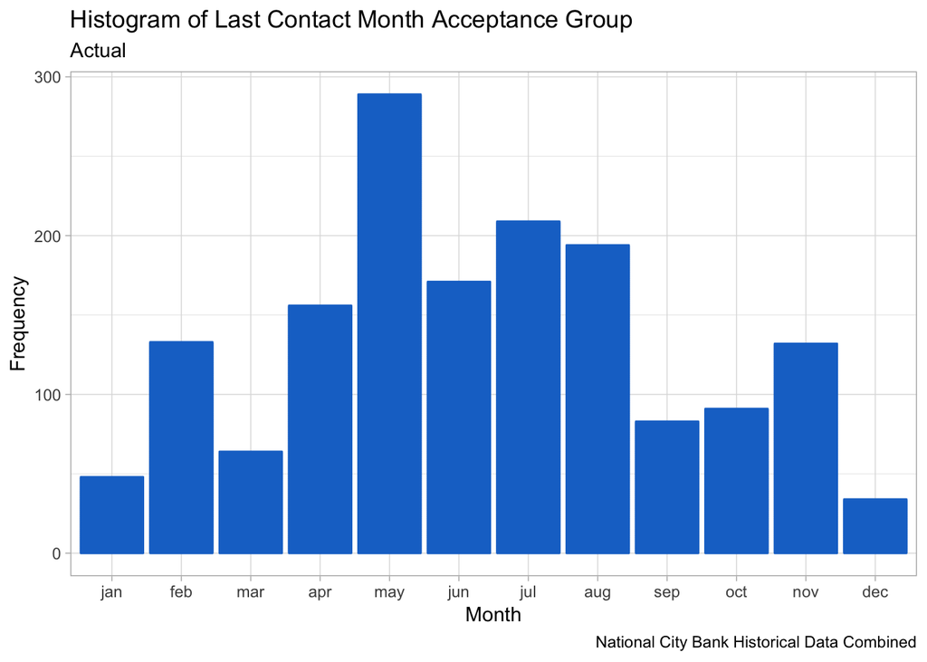

```r
historical.accepters$LastContactMonth <- factor(
  historical.accepters$LastContactMonth, levels = c( "jan", "feb", "mar",
                                                     "apr", "may", "jun",
                                                     "jul", "aug", "sep",
                                                     "oct", "nov", "dec" ) )

ggplot( historical.accepters, aes( x = LastContactMonth, y = Y_AcceptedOffer ) ) +
  geom_bar( stat = "identity", colour = "Dodgerblue3" ) +
  labs( title = "Histogram of Last Contact Month Acceptance Group",
       subtitle = "Actual",
       caption = "National City Bank Historical Data Combined",
       #tag = "Figure 8",
       x = "Month",
       y = "Frequency",
       colour = "Gears" ) +
  theme_light()
```

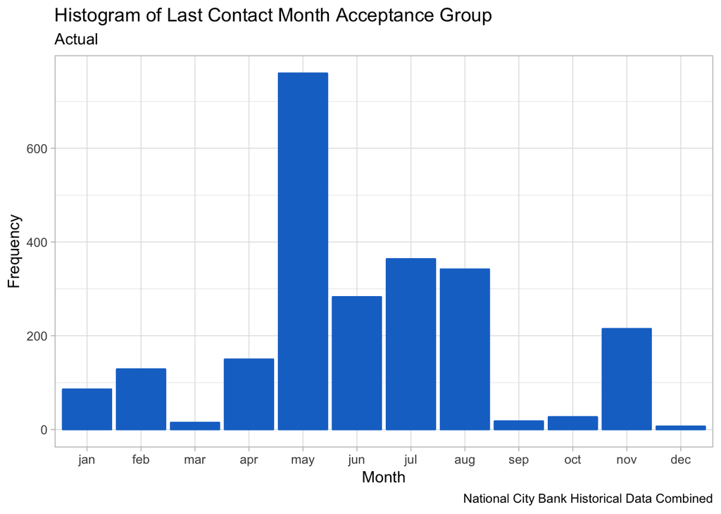

```r
historical.non.accepters <- hist.month.df[ hist.month.df$Y_AcceptedOffer == 0, ]
historical.non.accepters$Y_AcceptedOffer <- 1
historical.non.accepters$LastContactMonth <- factor(
  historical.non.accepters$LastContactMonth, levels = c( "jan", "feb", "mar",
                                                     "apr", "may", "jun",
                                                     "jul", "aug", "sep",
                                                     "oct", "nov", "dec" ) )

ggplot( historical.non.accepters, aes( x = LastContactMonth, y = Y_AcceptedOffer ) ) +
  geom_bar( stat = "identity", colour = "Dodgerblue3" ) +
  labs( title = "Histogram of Last Contact Month Acceptance Group",
       subtitle = "Actual",
       caption = "National City Bank Historical Data Combined",
       #tag = "Figure 8",
       x = "Month",
       y = "Frequency",
       colour = "Gears" ) +
  theme_light()
```

Assess car model

```r
carMake.df <- combined.historical.df[, c( "carMake", "Y_AcceptedOffer")]
carMake.df$Accept <- carMake.df$Y_AcceptedOffer
carMake.df$NotAccept <- carMake.df$Y_AcceptedOffer
head(carMake.df)
```

|  | carMake | Y_AcceptedOffer | Accept | NotAccept |
| --- | --- | --- | --- | --- |
| 1 | Mitsubishi | 0 | 0 | 0 |
| 2 | Hyundai | 0 | 0 | 0 |
| 3 | Ford | 1 | 1 | 1 |
| 4 | Buick | 1 | 1 | 1 |
| 5 | Isuzu | 0 | 0 | 0 |
| 6 | Hyundai | 1 | 1 | 1 |

```r
summary(carMake.df)
```

```
##       carMake     Y_AcceptedOffer     Accept        NotAccept
##  Chevrolet: 333   Min.   :0.000   Min.   :0.000   Min.   :0.000
##  Ford     : 325   1st Qu.:0.000   1st Qu.:0.000   1st Qu.:0.000
##  Dodge    : 205   Median :0.000   Median :0.000   Median :0.000
##  Toyota   : 189   Mean   :0.401   Mean   :0.401   Mean   :0.401
##  GMC      : 179   3rd Qu.:1.000   3rd Qu.:1.000   3rd Qu.:1.000
##  Mazda    : 151   Max.   :1.000   Max.   :1.000   Max.   :1.000
##  (Other)  :2618
```

```r
carMake.df$Accept[ carMake.df$Y_AcceptedOffer == 1 ] <- 1
carMake.df$Accept[ carMake.df$Y_AcceptedOffer == 0 ] <- 0
carMake.df$NotAccept[ carMake.df$Y_AcceptedOffer == 1 ] <- 0
carMake.df$NotAccept[ carMake.df$Y_AcceptedOffer == 0 ] <- 1
head(carMake.df)
```

|  | carMake | Y_AcceptedOffer | Accept | NotAccept |
| --- | --- | --- | --- | --- |
| 1 | Mitsubishi | 0 | 0 | 1 |
| 2 | Hyundai | 0 | 0 | 1 |
| 3 | Ford | 1 | 1 | 0 |
| 4 | Buick | 1 | 1 | 0 |
| 5 | Isuzu | 0 | 0 | 1 |
| 6 | Hyundai | 1 | 1 | 0 |

```r
carMake.df$Y_AcceptedOffer <- NULL
head(carMake.df)
```

|  | carMake | Accept | NotAccept |
| --- | --- | --- | --- |
| 1 | Mitsubishi | 0 | 1 |
| 2 | Hyundai | 0 | 1 |
| 3 | Ford | 1 | 0 |
| 4 | Buick | 1 | 0 |
| 5 | Isuzu | 0 | 1 |
| 6 | Hyundai | 1 | 0 |

```r
accept.carmake <- carMake.df[ carMake.df$Accept == 1, ]
notaccept.carmake <- carMake.df[ carMake.df$Accept == 0, ]

summary( accept.carmake )
```

```
##        carMake         Accept    NotAccept
##  Ford      : 140   Min.   :1   Min.   :0
##  Chevrolet : 139   1st Qu.:1   1st Qu.:0
##  Dodge     :  87   Median :1   Median :0
##  Toyota    :  74   Mean   :1   Mean   :0
##  GMC       :  65   3rd Qu.:1   3rd Qu.:0
##  Mitsubishi:  64   Max.   :1   Max.   :0
##  (Other)   :1035
```

```r
summary( carMake.df )
```

```
##       carMake         Accept        NotAccept
##  Chevrolet: 333   Min.   :0.000   Min.   :0.000
##  Ford     : 325   1st Qu.:0.000   1st Qu.:0.000
##  Dodge    : 205   Median :0.000   Median :1.000
##  Toyota   : 189   Mean   :0.401   Mean   :0.599
##  GMC      : 179   3rd Qu.:1.000   3rd Qu.:1.000
##  Mazda    : 151   Max.   :1.000   Max.   :1.000
##  (Other)  :2618
```

### 4. Reduce the data dimension

Parsimony is a desirable feature in a model. We will therefore exclude variables that we do not deem useful for our analysis, based on careful selection. As such, we reduce the data dimension.

Because we want to classify the customers most likely to accept the offer to allocate marketing resources to we want to look at data except for information about communication. We will therefore exclude all communication related data from the training data.

Additionally, we will exclude other variables that are not we deem not useful (as described in section 3).

```r
# drop non-overlapping variables
combined.historical.df$CallEnd        <- NULL
combined.historical.df$CallStart      <- NULL
combined.historical.df$CallDuration   <- NULL

# drop carModel (too many factors)
combined.historical.df$carModel       <- NULL
combined.prospects.df$carModel        <- NULL

# drop DaysPassed (too many NAs)
combined.historical.df$DaysPassed     <- NULL
combined.prospects.df$DaysPassed      <- NULL

# drop PreviousAttempts and Outcome (conflicting with our Y variable and too many NA)
combined.historical.df$PrevAttempts   <- NULL
combined.historical.df$Outcome        <- NULL

combined.prospects.df$PrevAttempts    <- NULL
combined.prospects.df$Outcome         <- NULL

# exclude other communicastion data

combined.historical.df$Communication   <- NULL
combined.historical.df$LastContactDay  <- NULL
combined.historical.df$LastContactMonth<- NULL
combined.historical.df$NoOfContacts    <- NULL

combined.prospects.df$Communication   <- NULL
combined.prospects.df$LastContactDay  <- NULL
combined.prospects.df$LastContactMonth<- NULL
combined.prospects.df$NoOfContacts    <- NULL

# examine data sets
head( combined.historical.df )
```

|  | HHuniqueID | Y_AcceptedOffer | headOfhouseholdGender | annualDonations | EstRace | PetsPurchases | DigitalHabits_5_AlwaysOn | AffluencePurchases | Age | Job | Marital | Education | DefaultOnRecord | RecentBalance | HHInsurance | CarLoan | carMake | carYr |
| --- | --- | --- | --- | --- | --- | --- | --- | --- | --- | --- | --- | --- | --- | --- | --- | --- | --- | --- |
| 1 | HHd4d0af8c72 | 0 | F | NA | Fijian | TRUE | 4 | FALSE | 32 | management | single | tertiary | 0 | 1218 | 1 | 0 | Mitsubishi | 2004 |
| 2 | HH8d3e87c164 | 0 | M | NA |  | TRUE | 2 | FALSE | 32 | blue-collar | married | primary | 0 | 1156 | 1 | 0 | Hyundai | 1999 |
| 3 | HHdd53ef1db6 | 1 | F | NA |  | FALSE | 1 | FALSE | 29 | management | single | tertiary | 0 | 637 | 1 | 0 | Ford | 2001 |
| 4 | HH6fa0de6516 | 1 | F | NA |  | TRUE | 1 | TRUE | 25 | student | single | primary | 0 | 373 | 1 | 0 | Buick | 1998 |
| 5 | HHeb436ca7cf | 0 | F | NA | Paraguayan | TRUE | 3 | TRUE | 30 | management | married | tertiary | 0 | 2694 | 0 | 0 | Isuzu | 1998 |
| 6 | HH5119beb3cd | 1 | F | NA |  | TRUE | 3 | FALSE | 32 | technician | single | tertiary | 0 | 1625 | 0 | 0 | Hyundai | 2003 |

```r
head( combined.prospects.df )
```

|  | HHuniqueID | Y_AcceptedOffer | headOfhouseholdGender | annualDonations | EstRace | PetsPurchases | DigitalHabits_5_AlwaysOn | AffluencePurchases | Age | Job | Marital | Education | DefaultOnRecord | RecentBalance | HHInsurance | CarLoan | carMake | carYr |
| --- | --- | --- | --- | --- | --- | --- | --- | --- | --- | --- | --- | --- | --- | --- | --- | --- | --- | --- |
| 1 | HH0534604f12 | NA | F | NA |  | TRUE | 4 | FALSE | 25 | admin. | single | secondary | 0 | 1 | 1 | 1 | GMC | 2004 |
| 2 | HH5e71c6ec08 | NA | M | NA |  | TRUE | 4 | FALSE | 40 | management | married | tertiary | 0 | 0 | 1 | 1 | Chevrolet | NA |
| 3 | HH4cd1f61b84 | NA | M | NA |  | TRUE | 4 | TRUE | 44 | management | single | tertiary | 0 | -1313 | 1 | 1 | Toyota | 2003 |
| 4 | HHf444cf2934 | NA | M | NA |  | FALSE | 2 | TRUE | 27 | services | single | secondary | 0 | 6279 | 1 | 0 | GMC | 2002 |
| 5 | HHc78254e402 | NA | F | NA |  | FALSE | 5 | FALSE | 53 | technician | married | secondary | 0 | 7984 | 1 | 0 | Volvo | 2013 |
| 6 | HH4972605e6f | NA | M | NA | Delaware | FALSE | 3 | TRUE | 28 | management | single | tertiary | 0 | 12956 | 1 | 0 | Hyundai | 2005 |

### 5. Determine the data mining task

From a list of 1,000 prospects, identify the top 100 with the highest probability of accepting the product offer.

### 6. Partition the data

We partition the combined historical data into a training (60%) and validation (40%) set.

```r
# Partition the data
set.seed( 1234 )
splitPercent <- round( nrow( combined.historical.df ) %*% 0.6 )
totalRecords <- 1:nrow( combined.historical.df )
idx <- sample( totalRecords, splitPercent )

trainDat <- combined.historical.df[idx,]
validDat <- combined.historical.df[-idx,]
```

Next, we create a treatment plan and treat our data. Because this is a classification problem, we use designTreatmentC() of the vtreat package.

```r
# get variable names
names( trainDat )
```

```
##  [1] "HHuniqueID"               "Y_AcceptedOffer"
##  [3] "headOfhouseholdGender"    "annualDonations"
##  [5] "EstRace"                  "PetsPurchases"
##  [7] "DigitalHabits_5_AlwaysOn" "AffluencePurchases"
##  [9] "Age"                      "Job"
## [11] "Marital"                  "Education"
## [13] "DefaultOnRecord"          "RecentBalance"
## [15] "HHInsurance"              "CarLoan"
## [17] "carMake"                  "carYr"
```

```r
# select the variables to treat
xVars <- c( "headOfhouseholdGender", "annualDonations",
            "EstRace", "PetsPurchases", "DigitalHabits_5_AlwaysOn",
            "AffluencePurchases", "Age", "Job", "Marital", "Education",
            "DefaultOnRecord", "RecentBalance", "HHInsurance", "CarLoan",
            "carMake", "carYr" )

# create a treatment plan and declare what outcome is a success (1, offer accepted)
treatmentplan <- designTreatmentsC( trainDat, xVars,'Y_AcceptedOffer', 1 )
```

```
## [1] "vtreat 1.3.1 inspecting inputs Mon Dec 10 10:16:09 2018"
## [1] "designing treatments Mon Dec 10 10:16:09 2018"
## [1] " have initial level statistics Mon Dec 10 10:16:09 2018"
## [1] " scoring treatments Mon Dec 10 10:16:09 2018"
## [1] "have treatment plan Mon Dec 10 10:16:10 2018"
## [1] "rescoring complex variables Mon Dec 10 10:16:10 2018"
## [1] "done rescoring complex variables Mon Dec 10 10:16:11 2018"
```

Prepare the data with treatment plan.

When we examine the data we observe that new binary variables have been created for the factor variables.

```r
# prepare the data using our treatmentplan
treatedTrain <- prepare( treatmentplan, trainDat )

# examine dataframe
head( treatedTrain, 4)
```

|  | annualDonations_clean | annualDonations_isBAD | EstRace_catP | EstRace_catB | PetsPurchases_clean | DigitalHabits_5_AlwaysOn_clean | AffluencePurchases_clean | Age_clean | Job_catP | Job_catB | Marital_catP | Marital_catB | Education_catP | Education_catB | DefaultOnRecord_clean | RecentBalance_clean | HHInsurance_clean | CarLoan_clean | carMake_catP | carMake_catB | carYr_clean | carYr_isBAD | headOfhouseholdGender_lev_x_F | headOfhouseholdGender_lev_x_M | EstRace_lev_x_ | Job_lev_x_admin_ | Job_lev_x_blue_collar | Job_lev_x_entrepreneur | Job_lev_x_housemaid | … |
| --- | --- | --- | --- | --- | --- | --- | --- | --- | --- | --- | --- | --- | --- | --- | --- | --- | --- | --- | --- | --- | --- | --- | --- | --- | --- | --- | --- | --- | --- | --- |
| 1 | 644.8435 | 1 | 0.006250000 | 5.520756e-06 | 1 | 3 | 0 | 42 | 0.2295833 | 0.197825785 | 0.5616667 | -0.1708006 | 0.0425000 | 0.6817179 | 0 | 1519 | 0 | 0 | 0.024583333 | 0.3715636 | 2006 | 0 | 0 | 1 | 0 | 0 | 0 | 0 | 0 | … |
| 2 | 644.8435 | 1 | 0.003333333 | 4.054651e-01 | 0 | 3 | 1 | 38 | 0.1675000 | 0.002072711 | 0.5616667 | -0.1708006 | 0.5012500 | -0.2101047 | 0 | 4539 | 0 | 0 | 0.009166667 | 0.5877850 | 2005 | 0 | 0 | 1 | 0 | 0 | 0 | 0 | 0 | … |
| 3 | 644.8435 | 1 | 0.759583333 | 4.052456e-02 | 1 | 2 | 1 | 30 | 0.1675000 | 0.002072711 | 0.3162500 | 0.2231436 | 0.3220833 | 0.2785161 | 0 | 880 | 1 | 1 | 0.007500000 | -0.2876738 | 1986 | 0 | 1 | 0 | 1 | 0 | 0 | 0 | 0 | … |
| 4 | 644.8435 | 1 | 0.002500000 | -2.876571e-01 | 0 | 2 | 0 | 41 | 0.1887500 | -0.483173681 | 0.5616667 | -0.1708006 | 0.5012500 | -0.2101047 | 0 | 429 | 1 | 0 | 0.020416667 | 0.2006715 | 2008 | 0 | 0 | 1 | 0 | 0 | 1 | 0 | 0 | … |

```r
names( treatedTrain )
```

```
##  [1] "annualDonations_clean"          "annualDonations_isBAD"
##  [3] "EstRace_catP"                   "EstRace_catB"
##  [5] "PetsPurchases_clean"            "DigitalHabits_5_AlwaysOn_clean"
##  [7] "AffluencePurchases_clean"       "Age_clean"
##  [9] "Job_catP"                       "Job_catB"
## [11] "Marital_catP"                   "Marital_catB"
## [13] "Education_catP"                 "Education_catB"
## [15] "DefaultOnRecord_clean"          "RecentBalance_clean"
## [17] "HHInsurance_clean"              "CarLoan_clean"
## [19] "carMake_catP"                   "carMake_catB"
## [21] "carYr_clean"                    "carYr_isBAD"
## [23] "headOfhouseholdGender_lev_x_F"  "headOfhouseholdGender_lev_x_M"
## [25] "EstRace_lev_x_"                 "Job_lev_x_admin_"
## [27] "Job_lev_x_blue_collar"          "Job_lev_x_entrepreneur"
## [29] "Job_lev_x_housemaid"            "Job_lev_x_management"
```

[output cut: 16 more lines]

### 7. Choose the data mining techniques

We will apply k-Nearest Neighbours (k-NN) for this data mining task.

k-Nearest Neighbors method identifies k records in the training data that are similar to a new record we want to classify. - Pro: simplicity, no parameter estimation - Con: computationally expensive

We use the classes (Accept/Not Accept) of ‘neighbors’ of our Prospects to assign a probability a Prospect will accept the offer.

A higher value of k allows for smoothing and reduces the risk of overfitting. Too high value for k limits the model’s ability to capture local structures in the data.

### 8. Use algorithm to perform the task

We will train the model using k-NN algorithm from the caret package.

```r
knnFit <- train(as.factor( Y_AcceptedOffer ) ~ .,
                data = treatedTrain,
                method = "knn",
                preProcess = c( "center","scale" ) ) # normalization
```

When we evaluate the model, we can observe the model use k = 9, the largest value for k under the default settings. This suggest that it may be possible to further optimize the model when we allow for a greater value for k.

```r
knnFit
```

```
## k-Nearest Neighbors
##
## 2400 samples
##   60 predictor
##    2 classes: '0', '1'
##
## Pre-processing: centered (60), scaled (60)
## Resampling: Bootstrapped (25 reps)
## Summary of sample sizes: 2400, 2400, 2400, 2400, 2400, 2400, ...
## Resampling results across tuning parameters:
##
##   k  Accuracy   Kappa
##   5  0.5729225  0.09967886
##   7  0.5738301  0.09698190
##   9  0.5741387  0.09152331
##
## Accuracy was used to select the optimal model using the largest value.
## The final value used for the model was k = 9.
```

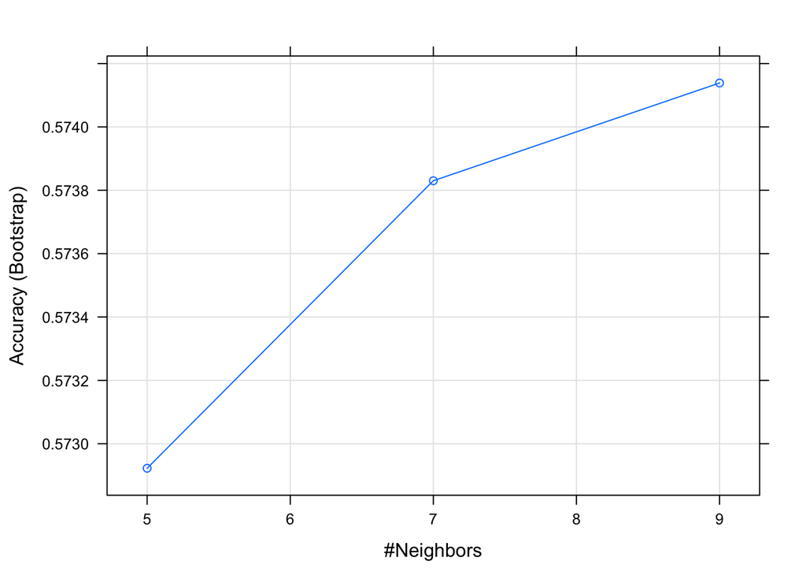

```r
plot( knnFit )
```

We can expand the search for optimal k by using the tuneLenght parameter, we set it to 10.

```r
knnFit <- train(as.factor( Y_AcceptedOffer ) ~ .,
                data = treatedTrain,
                method = "knn",
                preProcess = c( "center","scale" ), # normalization
                tuneLength = 10 )
```

We can evaluate the model by plotting the object. The final value for k was 23, resulting in an accuracy of 0.5987, or 59.87%.

```r
knnFit
```

```
## k-Nearest Neighbors
##
## 2400 samples
##   60 predictor
##    2 classes: '0', '1'
##
## Pre-processing: centered (60), scaled (60)
## Resampling: Bootstrapped (25 reps)
## Summary of sample sizes: 2400, 2400, 2400, 2400, 2400, 2400, ...
## Resampling results across tuning parameters:
##
##   k   Accuracy   Kappa
##    5  0.5705747  0.09046371
##    7  0.5761597  0.09747221
##    9  0.5774762  0.09318646
##   11  0.5810413  0.09708396
##   13  0.5828553  0.09614547
##   15  0.5894003  0.10649508
##   17  0.5906221  0.10615335
##   19  0.5923564  0.10775997
##   21  0.5942841  0.11065831
##   23  0.5987862  0.11904171
##
## Accuracy was used to select the optimal model using the largest value.
## The final value used for the model was k = 23.
```

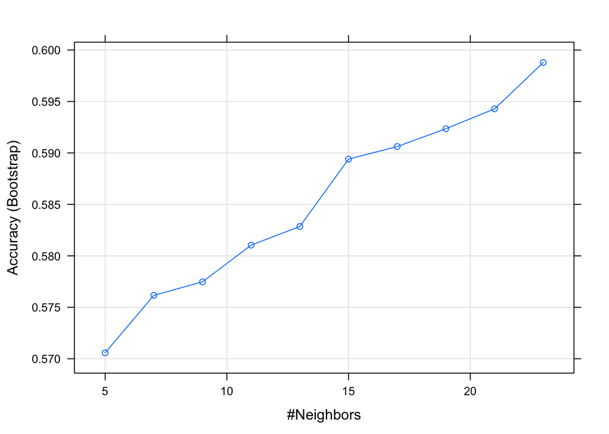

```r
plot( knnFit )
```

When we run the model on the training set and assess its performance we observe an accuracy of 65.46%.

```r
# make predictions on the training data
trainClasses <- predict(knnFit, treatedTrain )
confusionMatrix( as.factor( trainDat$Y_AcceptedOffer ), trainClasses )
```

```
## Confusion Matrix and Statistics
##
##           Reference
## Prediction    0    1
##          0 1209  231
##          1  598  362
##
##                Accuracy : 0.6546
##                  95% CI : (0.6352, 0.6736)
##     No Information Rate : 0.7529
##     P-Value [Acc > NIR] : 1
##
##                   Kappa : 0.2314
##  Mcnemar's Test P-Value : <2e-16
##
##             Sensitivity : 0.6691
##             Specificity : 0.6105
##          Pos Pred Value : 0.8396
##          Neg Pred Value : 0.3771
##              Prevalence : 0.7529
##          Detection Rate : 0.5038
##    Detection Prevalence : 0.6000
##       Balanced Accuracy : 0.6398
##
##        'Positive' Class : 0
##
```

Next, we treat the validation data using our treatment plan and use our k-NN fitted model to predict whether customer accepted the offer.

We obtain a 61.8% accuracy on the validation set.

```r
# prepare the validation data using our treatmentplan
treatedValid <- prepare( treatmentplan, validDat )

# make predictions on the validation data
validClasses <- predict( knnFit, treatedValid )
confusionMatrix( as.factor( validDat$Y_AcceptedOffer ), validClasses )
```

```
## Confusion Matrix and Statistics
##
##           Reference
## Prediction   0   1
##          0 780 176
##          1 435 209
##
##                Accuracy : 0.6181
##                  95% CI : (0.5938, 0.642)
##     No Information Rate : 0.7594
##     P-Value [Acc > NIR] : 1
##
##                   Kappa : 0.1503
##  Mcnemar's Test P-Value : <2e-16
##
##             Sensitivity : 0.6420
##             Specificity : 0.5429
##          Pos Pred Value : 0.8159
##          Neg Pred Value : 0.3245
##              Prevalence : 0.7594
##          Detection Rate : 0.4875
##    Detection Prevalence : 0.5975
##       Balanced Accuracy : 0.5924
##
##        'Positive' Class : 0
##
```

```r
Accuracy( validClasses, validDat$Y_AcceptedOffer )
```

```
## [1] 0.618125
```

```r
validProbs <- predict( knnFit, treatedValid, type = c( 'prob' ) )
head( validProbs )
```

|  | 0 | 1 |
| --- | --- | --- |
| 1 | 0.6086957 | 0.3913043 |
| 2 | 0.4347826 | 0.5652174 |
| 3 | 0.7826087 | 0.2173913 |
| 4 | 0.7391304 | 0.2608696 |
| 5 | 0.6521739 | 0.3478261 |
| 6 | 0.6956522 | 0.3043478 |

To assess our models predictive performance we can create lift charts. First, we create a data frame that contains the acctual outcome.

```r
# create data frame
valid.lift.data <- validProbs
# combine outcome column using cbind
valid.lift.data <- cbind( valid.lift.data, treatedValid$Y_AcceptedOffer )
colnames( valid.lift.data )[ colnames( valid.lift.data )
                             == "treatedValid$Y_AcceptedOffer" ] <- "actual"
colnames( valid.lift.data )[ colnames( valid.lift.data )
                             == "1" ] <- "prob"
valid.lift.data$`0` <- NULL
head( valid.lift.data )
```

|  | prob | actual |
| --- | --- | --- |
| 1 | 0.3913043 | 0 |
| 2 | 0.5652174 | 1 |
| 3 | 0.2173913 | 0 |
| 4 | 0.2608696 | 0 |
| 5 | 0.3478261 | 1 |
| 6 | 0.3043478 | 0 |

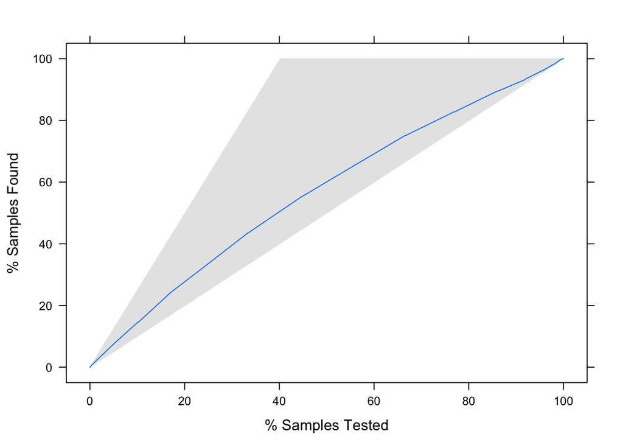

```r
# create object for lift chart
valid.lift <- lift( relevel( as.factor( actual ), ref = "1" ) ~ prob,
                    data = valid.lift.data )
xyplot( valid.lift, plot = "gain" )
```

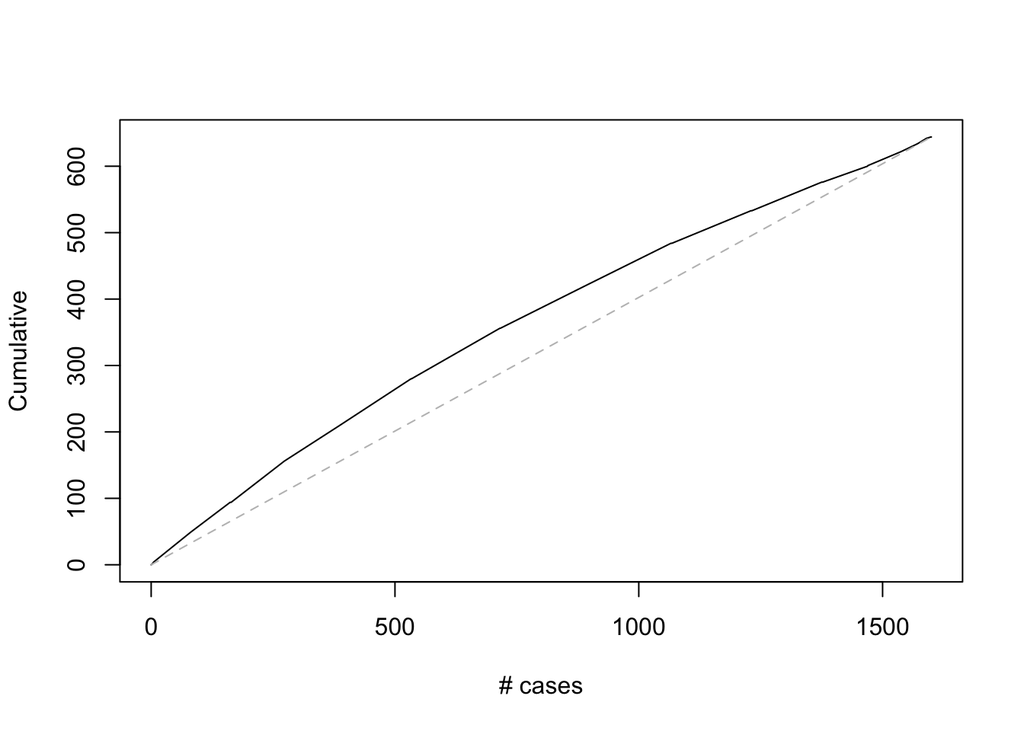

```r
# second lift chart
gain <- gains( valid.lift.data$actual,
               valid.lift.data$prob,
               groups = dim( valid.lift.data )[1] )
plot( c( 0, gain$cume.pct.of.total * sum( valid.lift.data$actual ) ) ~
        c( 0, gain$cume.obs ),
      xlab = "# cases",
      ylab = "Cumulative",
      type = "l" )
lines( c( 0, sum( valid.lift.data$actual ) ) ~ c( 0, dim( valid.lift.data )[1] ),
       col = "grey", lty = 2 )
```

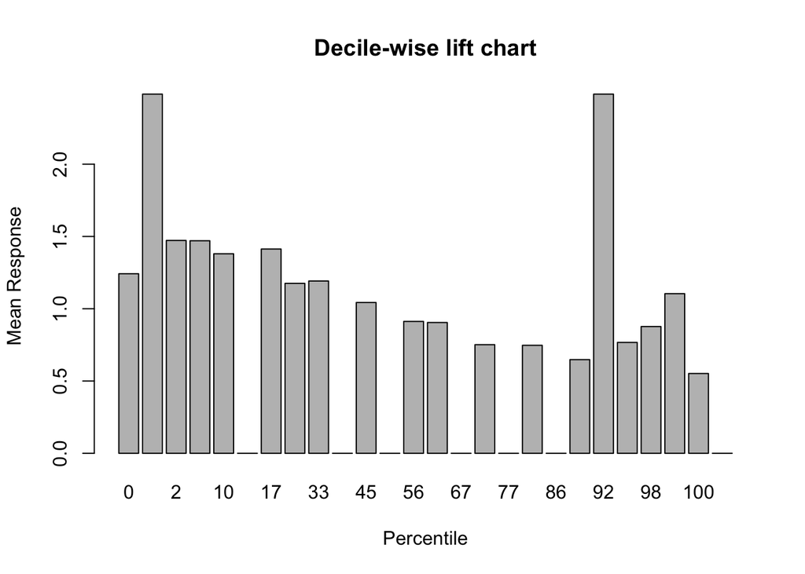

```r
# decile-wise lift chart, using gains() to compute deciles
gain.deciles <- gains( valid.lift.data$actual, valid.lift.data$prob )
barplot( gain$mean.resp / mean( valid.lift.data$actual ),
         names.arg = gain$depth,
         xlab = "Percentile",
         ylab = "Mean Response",
         main = "Decile-wise lift chart" )
```

When we run our k-NN model on new unseen data, we get the following predictions.

```r
# prepare the new unseen data using our treatmentplan
treatedProspects <- prepare( treatmentplan, combined.prospects.df )

# make predictions for the prospects data
ProspectsClasses <- predict( knnFit, treatedProspects )

# View results
summary( ProspectsClasses )
```

```
##   0   1
## 754 246
```

We can create a probability table for the prospects and select a subset of the top 100 prospects (most likely to accept the offer).

```r
# predict probabilities
prospectsProbs <- predict( knnFit, treatedProspects, type = c( 'prob' ) )
# add ID column and change order of columns in data frame
prospectsProbs$HHuniqueID <- combined.prospects.df$HHuniqueID
prospectsProbs <- prospectsProbs[, c( 3, 2, 1 )]
# change column names
prospectsProbs <- rename( prospectsProbs, "No" = "0", "Yes" = "1" )
# sort descending
sorted.prospectsProbs <- arrange( prospectsProbs, desc( Yes ) )
# select top 100 prospects
prospect.top.100 <- sorted.prospectsProbs[1:100, ]
head( prospect.top.100 )
```

|  | HHuniqueID | Yes | No |
| --- | --- | --- | --- |
| 1 | HH580d21659e | 0.7391304 | 0.2608696 |
| 2 | HH25ed28726e | 0.7391304 | 0.2608696 |
| 3 | HH4eea90b050 | 0.7391304 | 0.2608696 |
| 4 | HH127ebc9974 | 0.7391304 | 0.2608696 |
| 5 | HH2b5e426863 | 0.7391304 | 0.2608696 |
| 6 | HH345507e9aa | 0.7391304 | 0.2608696 |

Finally, we want to test the robustness of the model. That is, have the model run several times, learning from different random samples. For this task we created a new function, bank.knn.model.simulator().

```r
bank.knn.model.simulator <- function( number.of.loops, dataset ) {

   accuracy.data.frame <<- data.frame(
    Training = 0,
    Validation = 0 )

  for( i in 1:number.of.loops ) {

    splitPercent  <- round( nrow( dataset ) %*% 0.6 )
    totalRecords  <- 1:nrow( dataset )
    idx           <- sample( totalRecords, splitPercent )
    trainDat      <- combined.historical.df[idx,]
    validDat      <- combined.historical.df[-idx,]

    xVars <- c( "headOfhouseholdGender", "annualDonations",
              "EstRace", "PetsPurchases", "DigitalHabits_5_AlwaysOn",
              "AffluencePurchases", "Age", "Job", "Marital", "Education",
              "DefaultOnRecord", "RecentBalance", "HHInsurance", "CarLoan",
              "carMake", "carYr" )

    treatmentplan <- designTreatmentsC( trainDat, xVars,'Y_AcceptedOffer', 1 )
    treatedTrain  <- prepare( treatmentplan, trainDat )
    treatedValid  <- prepare( treatmentplan, validDat )

    knnFit <- train( as.factor( Y_AcceptedOffer ) ~ .,
                data = treatedTrain,
                method = "knn",
                preProcess = c( "center","scale" ),
                tuneLength = 10 )

    trainClasses <- predict( knnFit, treatedTrain )
    accuracy.data.frame[ i, 1 ] <<- Accuracy( trainClasses, trainDat$Y_AcceptedOffer )
    validClasses <- predict( knnFit, treatedValid )
    accuracy.data.frame[ i, 2 ] <<- Accuracy( validClasses, validDat$Y_AcceptedOffer )
  }
  message( "Mean Training Accuracy: ",
           mean( accuracy.data.frame$Training, na.rm = TRUE ) )
  message( "Mean Validation Accuracy: ",
           mean( accuracy.data.frame$Validation, na.rm = TRUE ) )

  setwd("/Users/TdR/Coding/R/HarvardDataMiningCourse/cases/National City Bank")
  jpeg( "Accuracy_Boxplot" )
  boxplot( accuracy.data.frame$Training, accuracy.data.frame$Validation,
         pch = 1,
         col = c("darkgreen", "navyblue"),
         ylab = "Accuracy",
         xlab = "Training (left) and Validation (right)",
         main = "Boxplot of Model Accuracy on Training and Validation Set" )
  dev.off()
}
```

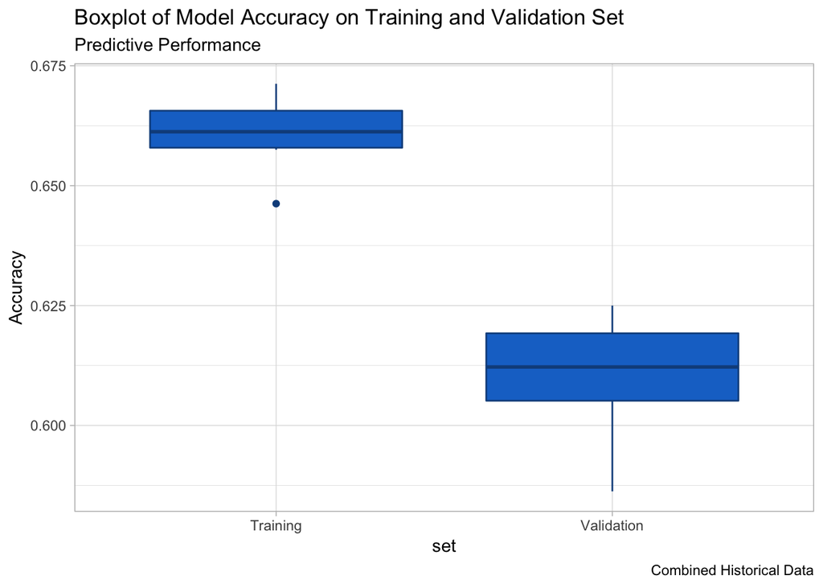

```r
boxplot.accuracy.df <- data.frame( accuracy = 1:20, set = 1:20 )
boxplot.accuracy.df$accuracy[1:10] <- accuracy.data.frame$Training
boxplot.accuracy.df$accuracy[11:20] <- accuracy.data.frame$Validation
boxplot.accuracy.df$set[1:10] <- c( "Training" )
boxplot.accuracy.df$set[11:20] <- c( "Validation" )


p <- ggplot( boxplot.accuracy.df, aes( x = set, y = accuracy ) ) +
  geom_boxplot( fill = 'Dodgerblue3', color = "Dodgerblue4" ) +
  labs( title = "Boxplot of Model Accuracy on Training and Validation Set",
        subtitle = "Predictive Performance",
        caption = "Combined Historical Data",
        # tag = "Figure 8",
        y = "Accuracy",
        colour = "Gears" ) +
  theme_light()
p
```

### 9. Interpret the results of the algorithms

We got an average training accuracy of 66% and a validation accruacy of 61%, suggesting that we have some overfitting. Although the model performs better than selecting prospects randomly, for this data mining task our goal is to achieve higher predictive power than this model is able to achieve. We will therefore explore other algorithms, including Regression Trees, Random Forest, and Logistic Regression.

### 10. Deploy the model